# Taller3-Kmeans

```python
import pandas as pd
import numpy as np
import matplotlib.pyplot as plt
import pandas_profiling #funcion para ver missing values por variables en DF**
import seaborn as sns
from sklearn.preprocessing import StandardScaler
from  sklearn.pipeline import make_pipeline
from sklearn.preprocessing import LabelEncoder
from sklearn import preprocessing
from sklearn.cluster import KMeans
from sklearn.metrics import silhouette_samples, silhouette_score
from sklearn.decomposition import PCA
import mglearn
import warnings
import time
```

```python
def missing_values_table(df):
        mis_val = df.isnull().sum()
        mis_val_percent = 100 * df.isnull().sum()/len(df)
        mis_val_table = pd.concat([mis_val, mis_val_percent], axis=1)
        mis_val_table_ren_columns = mis_val_table.rename(
        columns = {0 : 'Missing Values', 1 : '% of Total Values'})
        return mis_val_table_ren_columns
```

```python
def kmeans_class_eva(data_):
    kmeans = KMeans(n_clusters=2)
    kmeans.fit(data_)
    kmeans.predict(data_)
    labels = kmeans.labels_
    # Create a DataFrame with labels and varieties as columns: df
    df_ = pd.DataFrame({'labels': labels, 'drink': df_full['Drink']})
    # Create crosstab: ct
    ct = pd.crosstab(df_['labels'],df_['drink'])
    # Display ct
    print(ct)
```

```python
def kmeans_silueta_eva(data_):
    n_cluster = range(2,10)
    for n in n_cluster:
        kmeans = KMeans(n_clusters=n)
        kmeans.fit(data_)
        kmeans.predict(data_)
        labels = kmeans.labels_
        silhouette_avg = silhouette_score(data_, labels)
        print("Para n_clusters = ", n ," El Valor del coeficiente silueta es :", silhouette_avg  )
```

## Data Processing

```python
df = pd.read_csv('Estudent Alcohol Consumption.csv',sep=";")
```

```python
df.shape
```

```
(395, 34)
```

```python
#valores omitidos por variable
missing_values_table(df)
```

|  | Missing Values | % of Total Values |
| --- | --- | --- |
| school | 0 | 0.0 |
| sex | 0 | 0.0 |
| age | 0 | 0.0 |
| address | 0 | 0.0 |
| famsize | 0 | 0.0 |
| Pstatus | 0 | 0.0 |
| Medu | 0 | 0.0 |
| Fedu | 0 | 0.0 |
| Mjob | 0 | 0.0 |
| Fjob | 0 | 0.0 |
| reason | 0 | 0.0 |
| guardian | 0 | 0.0 |
| traveltime | 0 | 0.0 |
| studytime | 0 | 0.0 |
| failures | 0 | 0.0 |
| schoolsup | 0 | 0.0 |
| famsup | 0 | 0.0 |
| paid | 0 | 0.0 |
| activities | 0 | 0.0 |
| nursery | 0 | 0.0 |
| higher | 0 | 0.0 |
| internet | 0 | 0.0 |
| romantic | 0 | 0.0 |
| famrel | 0 | 0.0 |
| freetime | 0 | 0.0 |
| goout | 0 | 0.0 |
| Dalc | 0 | 0.0 |
| Walc | 0 | 0.0 |
| health | 0 | 0.0 |
| absences | 0 | 0.0 |
| G1 | 0 | 0.0 |
| G2 | 0 | 0.0 |
| G3 | 0 | 0.0 |
| Alc | 0 | 0.0 |

```python
#dateccion duplicadso
df[df.duplicated()]
```

|  | school | sex | age | address | famsize | Pstatus | Medu | Fedu | Mjob | Fjob | ... | freetime | goout | Dalc | Walc | health | absences | G1 | G2 | G3 | Alc |
| --- | --- | --- | --- | --- | --- | --- | --- | --- | --- | --- | --- | --- | --- | --- | --- | --- | --- | --- | --- | --- | --- |

0 rows × 34 columns

Overview

Dataset info

| Number of variables | 34 |
| --- | --- |
| Number of observations | 395 |
| Total Missing (%) | 0.0% |
| Total size in memory | 105.0 KiB |
| Average record size in memory | 272.2 B |

Variables types

| Numeric | 16 |
| --- | --- |
| Categorical | 17 |
| Boolean | 0 |
| Date | 0 |
| Text (Unique) | 0 |
| Rejected | 1 |
| Unsupported | 0 |

Warnings

- `G2` has 13 / 3.3% zeros Zeros

- `G3` is highly correlated with `G2` (ρ = 0.90487) Rejected

- `absences` has 115 / 29.1% zeros Zeros

- `failures` has 312 / 79.0% zeros Zeros

Variables

Alc  
Numeric

| Distinct count | 5 |
| --- | --- |
| Unique (%) | 1.3% |
| Missing (%) | 0.0% |
| Missing (n) | 0 |
| Infinite (%) | 0.0% |
| Infinite (n) | 0 |

| Mean | 1.7165 |
| --- | --- |
| Minimum | 1 |
| Maximum | 5 |
| Zeros (%) | 0.0% |

Toggle details

**Statistics**

Quantile statistics

| Minimum | 1 |
| --- | --- |
| 5-th percentile | 1 |
| Q1 | 1 |
| Median | 1 |
| Q3 | 2 |
| 95-th percentile | 4 |
| Maximum | 5 |
| Range | 4 |
| Interquartile range | 1 |

Descriptive statistics

| Standard deviation | 0.96676 |
| --- | --- |
| Coef of variation | 0.56323 |
| Kurtosis | 1.7401 |
| Mean | 1.7165 |
| MAD | 0.77994 |
| Skewness | 1.4406 |
| Sum | 678 |
| Variance | 0.93463 |
| Memory size | 3.2 KiB |

**Histogram**

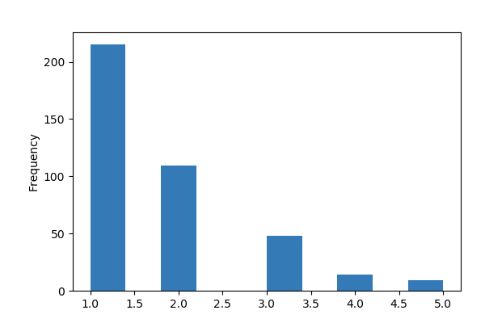

**Common Values**

| Value | Count | Frequency (%) |  |
| --- | --- | --- | --- |
| 1 | 215 | 54.4% |  |
| 2 | 109 | 27.6% |  |
| 3 | 48 | 12.2% |  |
| 4 | 14 | 3.5% |  |
| 5 | 9 | 2.3% |  |

**Extreme Values**

Minimum 5 values

| Value | Count | Frequency (%) |  |
| --- | --- | --- | --- |
| 1 | 215 | 54.4% |  |
| 2 | 109 | 27.6% |  |
| 3 | 48 | 12.2% |  |
| 4 | 14 | 3.5% |  |
| 5 | 9 | 2.3% |  |

Maximum 5 values

| Value | Count | Frequency (%) |  |
| --- | --- | --- | --- |
| 1 | 215 | 54.4% |  |
| 2 | 109 | 27.6% |  |
| 3 | 48 | 12.2% |  |
| 4 | 14 | 3.5% |  |
| 5 | 9 | 2.3% |  |

Dalc  
Numeric

| Distinct count | 5 |
| --- | --- |
| Unique (%) | 1.3% |
| Missing (%) | 0.0% |
| Missing (n) | 0 |
| Infinite (%) | 0.0% |
| Infinite (n) | 0 |

| Mean | 1.481 |
| --- | --- |
| Minimum | 1 |
| Maximum | 5 |
| Zeros (%) | 0.0% |

Toggle details

**Statistics**

Quantile statistics

| Minimum | 1 |
| --- | --- |
| 5-th percentile | 1 |
| Q1 | 1 |
| Median | 1 |
| Q3 | 2 |
| 95-th percentile | 3 |
| Maximum | 5 |
| Range | 4 |
| Interquartile range | 1 |

Descriptive statistics

| Standard deviation | 0.89074 |
| --- | --- |
| Coef of variation | 0.60144 |
| Kurtosis | 4.7595 |
| Mean | 1.481 |
| MAD | 0.6722 |
| Skewness | 2.1908 |
| Sum | 585 |
| Variance | 0.79342 |
| Memory size | 3.2 KiB |

**Histogram**

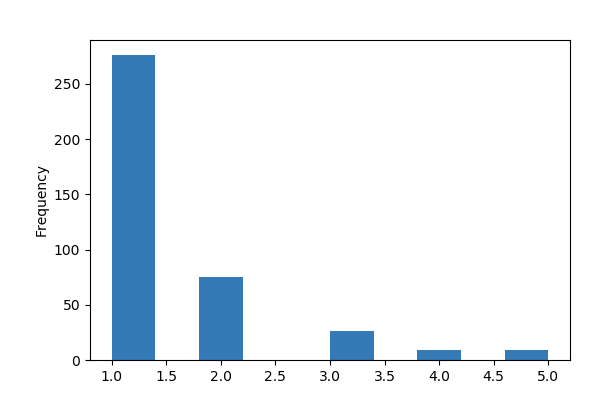

**Common Values**

| Value | Count | Frequency (%) |  |
| --- | --- | --- | --- |
| 1 | 276 | 69.9% |  |
| 2 | 75 | 19.0% |  |
| 3 | 26 | 6.6% |  |
| 5 | 9 | 2.3% |  |
| 4 | 9 | 2.3% |  |

**Extreme Values**

Minimum 5 values

| Value | Count | Frequency (%) |  |
| --- | --- | --- | --- |
| 1 | 276 | 69.9% |  |
| 2 | 75 | 19.0% |  |
| 3 | 26 | 6.6% |  |
| 4 | 9 | 2.3% |  |
| 5 | 9 | 2.3% |  |

Maximum 5 values

| Value | Count | Frequency (%) |  |
| --- | --- | --- | --- |
| 1 | 276 | 69.9% |  |
| 2 | 75 | 19.0% |  |
| 3 | 26 | 6.6% |  |
| 4 | 9 | 2.3% |  |
| 5 | 9 | 2.3% |  |

Fedu  
Numeric

| Distinct count | 5 |
| --- | --- |
| Unique (%) | 1.3% |
| Missing (%) | 0.0% |
| Missing (n) | 0 |
| Infinite (%) | 0.0% |
| Infinite (n) | 0 |

| Mean | 2.5215 |
| --- | --- |
| Minimum | 0 |
| Maximum | 4 |
| Zeros (%) | 0.5% |

Toggle details

**Statistics**

Quantile statistics

| Minimum | 0 |
| --- | --- |
| 5-th percentile | 1 |
| Q1 | 2 |
| Median | 2 |
| Q3 | 3 |
| 95-th percentile | 4 |
| Maximum | 4 |
| Range | 4 |
| Interquartile range | 1 |

Descriptive statistics

| Standard deviation | 1.0882 |
| --- | --- |
| Coef of variation | 0.43157 |
| Kurtosis | -1.1985 |
| Mean | 2.5215 |
| MAD | 0.96092 |
| Skewness | -0.031672 |
| Sum | 996 |
| Variance | 1.1842 |
| Memory size | 3.2 KiB |

**Histogram**

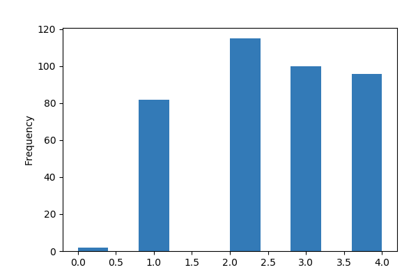

**Common Values**

| Value | Count | Frequency (%) |  |
| --- | --- | --- | --- |
| 2 | 115 | 29.1% |  |
| 3 | 100 | 25.3% |  |
| 4 | 96 | 24.3% |  |
| 1 | 82 | 20.8% |  |
| 0 | 2 | 0.5% |  |

**Extreme Values**

Minimum 5 values

| Value | Count | Frequency (%) |  |
| --- | --- | --- | --- |
| 0 | 2 | 0.5% |  |
| 1 | 82 | 20.8% |  |
| 2 | 115 | 29.1% |  |
| 3 | 100 | 25.3% |  |
| 4 | 96 | 24.3% |  |

Maximum 5 values

| Value | Count | Frequency (%) |  |
| --- | --- | --- | --- |
| 0 | 2 | 0.5% |  |
| 1 | 82 | 20.8% |  |
| 2 | 115 | 29.1% |  |
| 3 | 100 | 25.3% |  |
| 4 | 96 | 24.3% |  |

Fjob  
Categorical

| Distinct count | 5 |
| --- | --- |
| Unique (%) | 1.3% |
| Missing (%) | 0.0% |
| Missing (n) | 0 |

| other | 217 |
| --- | --- |
| services | 111 |
| teacher | 29 |
| Other values (2) | 38 |

Toggle details

| Value | Count | Frequency (%) |  |
| --- | --- | --- | --- |
| other | 217 | 54.9% |  |
| services | 111 | 28.1% |  |
| teacher | 29 | 7.3% |  |
| at_home | 20 | 5.1% |  |
| health | 18 | 4.6% |  |

G1  
Numeric

| Distinct count | 17 |
| --- | --- |
| Unique (%) | 4.3% |
| Missing (%) | 0.0% |
| Missing (n) | 0 |
| Infinite (%) | 0.0% |
| Infinite (n) | 0 |

| Mean | 10.909 |
| --- | --- |
| Minimum | 3 |
| Maximum | 19 |
| Zeros (%) | 0.0% |

Toggle details

**Statistics**

Quantile statistics

| Minimum | 3 |
| --- | --- |
| 5-th percentile | 6 |
| Q1 | 8 |
| Median | 11 |
| Q3 | 13 |
| 95-th percentile | 16 |
| Maximum | 19 |
| Range | 16 |
| Interquartile range | 5 |

Descriptive statistics

| Standard deviation | 3.3192 |
| --- | --- |
| Coef of variation | 0.30427 |
| Kurtosis | -0.69383 |
| Mean | 10.909 |
| MAD | 2.7514 |
| Skewness | 0.24061 |
| Sum | 4309 |
| Variance | 11.017 |
| Memory size | 3.2 KiB |

**Histogram**

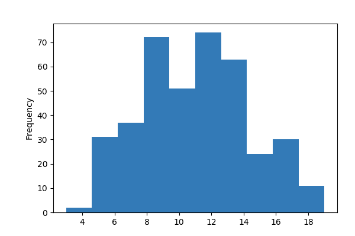

**Common Values**

| Value | Count | Frequency (%) |  |
| --- | --- | --- | --- |
| 10 | 51 | 12.9% |  |
| 8 | 41 | 10.4% |  |
| 11 | 39 | 9.9% |  |
| 7 | 37 | 9.4% |  |
| 12 | 35 | 8.9% |  |
| 13 | 33 | 8.4% |  |
| 9 | 31 | 7.8% |  |
| 14 | 30 | 7.6% |  |
| 15 | 24 | 6.1% |  |
| 6 | 24 | 6.1% |  |
| Other values (7) | 50 | 12.7% |  |

**Extreme Values**

Minimum 5 values

| Value | Count | Frequency (%) |  |
| --- | --- | --- | --- |
| 3 | 1 | 0.3% |  |
| 4 | 1 | 0.3% |  |
| 5 | 7 | 1.8% |  |
| 6 | 24 | 6.1% |  |
| 7 | 37 | 9.4% |  |

Maximum 5 values

| Value | Count | Frequency (%) |  |
| --- | --- | --- | --- |
| 15 | 24 | 6.1% |  |
| 16 | 22 | 5.6% |  |
| 17 | 8 | 2.0% |  |
| 18 | 8 | 2.0% |  |
| 19 | 3 | 0.8% |  |

G2  
Numeric

| Distinct count | 17 |
| --- | --- |
| Unique (%) | 4.3% |
| Missing (%) | 0.0% |
| Missing (n) | 0 |
| Infinite (%) | 0.0% |
| Infinite (n) | 0 |

| Mean | 10.714 |
| --- | --- |
| Minimum | 0 |
| Maximum | 19 |
| Zeros (%) | 3.3% |

Toggle details

**Statistics**

Quantile statistics

| Minimum | 0 |
| --- | --- |
| 5-th percentile | 5 |
| Q1 | 9 |
| Median | 11 |
| Q3 | 13 |
| 95-th percentile | 16.3 |
| Maximum | 19 |
| Range | 19 |
| Interquartile range | 4 |

Descriptive statistics

| Standard deviation | 3.7615 |
| --- | --- |
| Coef of variation | 0.35109 |
| Kurtosis | 0.62771 |
| Mean | 10.714 |
| MAD | 2.9421 |
| Skewness | -0.43165 |
| Sum | 4232 |
| Variance | 14.149 |
| Memory size | 3.2 KiB |

**Histogram**

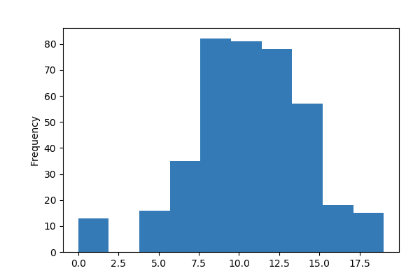

**Common Values**

| Value | Count | Frequency (%) |  |
| --- | --- | --- | --- |
| 9 | 50 | 12.7% |  |
| 10 | 46 | 11.6% |  |
| 12 | 41 | 10.4% |  |
| 13 | 37 | 9.4% |  |
| 11 | 35 | 8.9% |  |
| 15 | 34 | 8.6% |  |
| 8 | 32 | 8.1% |  |
| 14 | 23 | 5.8% |  |
| 7 | 21 | 5.3% |  |
| 5 | 15 | 3.8% |  |
| Other values (7) | 61 | 15.4% |  |

**Extreme Values**

Minimum 5 values

| Value | Count | Frequency (%) |  |
| --- | --- | --- | --- |
| 0 | 13 | 3.3% |  |
| 4 | 1 | 0.3% |  |
| 5 | 15 | 3.8% |  |
| 6 | 14 | 3.5% |  |
| 7 | 21 | 5.3% |  |

Maximum 5 values

| Value | Count | Frequency (%) |  |
| --- | --- | --- | --- |
| 15 | 34 | 8.6% |  |
| 16 | 13 | 3.3% |  |
| 17 | 5 | 1.3% |  |
| 18 | 12 | 3.0% |  |
| 19 | 3 | 0.8% |  |

G3  
Highly correlated

*This variable is highly correlated with `G2` and should be ignored for analysis*

| Correlation | 0.90487 |
| --- | --- |

Medu  
Numeric

| Distinct count | 5 |
| --- | --- |
| Unique (%) | 1.3% |
| Missing (%) | 0.0% |
| Missing (n) | 0 |
| Infinite (%) | 0.0% |
| Infinite (n) | 0 |

| Mean | 2.7494 |
| --- | --- |
| Minimum | 0 |
| Maximum | 4 |
| Zeros (%) | 0.8% |

Toggle details

**Statistics**

Quantile statistics

| Minimum | 0 |
| --- | --- |
| 5-th percentile | 1 |
| Q1 | 2 |
| Median | 3 |
| Q3 | 4 |
| 95-th percentile | 4 |
| Maximum | 4 |
| Range | 4 |
| Interquartile range | 2 |

Descriptive statistics

| Standard deviation | 1.0947 |
| --- | --- |
| Coef of variation | 0.39818 |
| Kurtosis | -1.09 |
| Mean | 2.7494 |
| MAD | 0.95517 |
| Skewness | -0.31838 |
| Sum | 1086 |
| Variance | 1.1984 |
| Memory size | 3.2 KiB |

**Histogram**

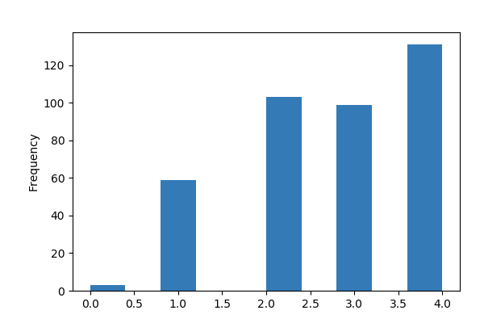

**Common Values**

| Value | Count | Frequency (%) |  |
| --- | --- | --- | --- |
| 4 | 131 | 33.2% |  |
| 2 | 103 | 26.1% |  |
| 3 | 99 | 25.1% |  |
| 1 | 59 | 14.9% |  |
| 0 | 3 | 0.8% |  |

**Extreme Values**

Minimum 5 values

| Value | Count | Frequency (%) |  |
| --- | --- | --- | --- |
| 0 | 3 | 0.8% |  |
| 1 | 59 | 14.9% |  |
| 2 | 103 | 26.1% |  |
| 3 | 99 | 25.1% |  |
| 4 | 131 | 33.2% |  |

Maximum 5 values

| Value | Count | Frequency (%) |  |
| --- | --- | --- | --- |
| 0 | 3 | 0.8% |  |
| 1 | 59 | 14.9% |  |
| 2 | 103 | 26.1% |  |
| 3 | 99 | 25.1% |  |
| 4 | 131 | 33.2% |  |

Mjob  
Categorical

| Distinct count | 5 |
| --- | --- |
| Unique (%) | 1.3% |
| Missing (%) | 0.0% |
| Missing (n) | 0 |

| other | 141 |
| --- | --- |
| services | 103 |
| at_home | 59 |
| Other values (2) | 92 |

Toggle details

| Value | Count | Frequency (%) |  |
| --- | --- | --- | --- |
| other | 141 | 35.7% |  |
| services | 103 | 26.1% |  |
| at_home | 59 | 14.9% |  |
| teacher | 58 | 14.7% |  |
| health | 34 | 8.6% |  |

Pstatus  
Categorical

| Distinct count | 2 |
| --- | --- |
| Unique (%) | 0.5% |
| Missing (%) | 0.0% |
| Missing (n) | 0 |

| T | 354 |
| --- | --- |
| A | 41 |

Toggle details

| Value | Count | Frequency (%) |  |
| --- | --- | --- | --- |
| T | 354 | 89.6% |  |
| A | 41 | 10.4% |  |

Walc  
Numeric

| Distinct count | 5 |
| --- | --- |
| Unique (%) | 1.3% |
| Missing (%) | 0.0% |
| Missing (n) | 0 |
| Infinite (%) | 0.0% |
| Infinite (n) | 0 |

| Mean | 2.2911 |
| --- | --- |
| Minimum | 1 |
| Maximum | 5 |
| Zeros (%) | 0.0% |

Toggle details

**Statistics**

Quantile statistics

| Minimum | 1 |
| --- | --- |
| 5-th percentile | 1 |
| Q1 | 1 |
| Median | 2 |
| Q3 | 3 |
| 95-th percentile | 5 |
| Maximum | 5 |
| Range | 4 |
| Interquartile range | 2 |

Descriptive statistics

| Standard deviation | 1.2879 |
| --- | --- |
| Coef of variation | 0.56212 |
| Kurtosis | -0.79085 |
| Mean | 2.2911 |
| MAD | 1.1124 |
| Skewness | 0.61196 |
| Sum | 905 |
| Variance | 1.6587 |
| Memory size | 3.2 KiB |

**Histogram**

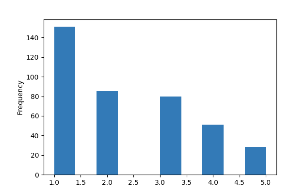

**Common Values**

| Value | Count | Frequency (%) |  |
| --- | --- | --- | --- |
| 1 | 151 | 38.2% |  |
| 2 | 85 | 21.5% |  |
| 3 | 80 | 20.3% |  |
| 4 | 51 | 12.9% |  |
| 5 | 28 | 7.1% |  |

**Extreme Values**

Minimum 5 values

| Value | Count | Frequency (%) |  |
| --- | --- | --- | --- |
| 1 | 151 | 38.2% |  |
| 2 | 85 | 21.5% |  |
| 3 | 80 | 20.3% |  |
| 4 | 51 | 12.9% |  |
| 5 | 28 | 7.1% |  |

Maximum 5 values

| Value | Count | Frequency (%) |  |
| --- | --- | --- | --- |
| 1 | 151 | 38.2% |  |
| 2 | 85 | 21.5% |  |
| 3 | 80 | 20.3% |  |
| 4 | 51 | 12.9% |  |
| 5 | 28 | 7.1% |  |

absences  
Numeric

| Distinct count | 34 |
| --- | --- |
| Unique (%) | 8.6% |
| Missing (%) | 0.0% |
| Missing (n) | 0 |
| Infinite (%) | 0.0% |
| Infinite (n) | 0 |

| Mean | 5.7089 |
| --- | --- |
| Minimum | 0 |
| Maximum | 75 |
| Zeros (%) | 29.1% |

Toggle details

**Statistics**

Quantile statistics

| Minimum | 0 |
| --- | --- |
| 5-th percentile | 0 |
| Q1 | 0 |
| Median | 4 |
| Q3 | 8 |
| 95-th percentile | 18.3 |
| Maximum | 75 |
| Range | 75 |
| Interquartile range | 8 |

Descriptive statistics

| Standard deviation | 8.0031 |
| --- | --- |
| Coef of variation | 1.4019 |
| Kurtosis | 21.719 |
| Mean | 5.7089 |
| MAD | 5.2026 |
| Skewness | 3.6716 |
| Sum | 2255 |
| Variance | 64.05 |
| Memory size | 3.2 KiB |

**Histogram**

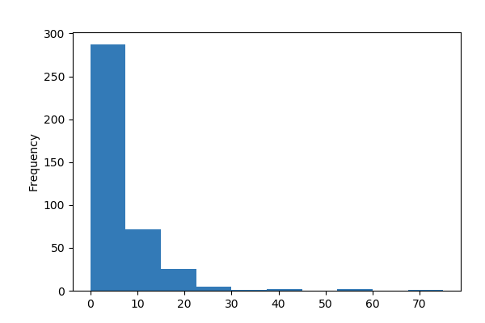

**Common Values**

| Value | Count | Frequency (%) |  |
| --- | --- | --- | --- |
| 0 | 115 | 29.1% |  |
| 2 | 65 | 16.5% |  |
| 4 | 53 | 13.4% |  |
| 6 | 31 | 7.8% |  |
| 8 | 22 | 5.6% |  |
| 10 | 17 | 4.3% |  |
| 14 | 12 | 3.0% |  |
| 12 | 12 | 3.0% |  |
| 3 | 8 | 2.0% |  |
| 7 | 7 | 1.8% |  |
| Other values (24) | 53 | 13.4% |  |

**Extreme Values**

Minimum 5 values

| Value | Count | Frequency (%) |  |
| --- | --- | --- | --- |
| 0 | 115 | 29.1% |  |
| 1 | 3 | 0.8% |  |
| 2 | 65 | 16.5% |  |
| 3 | 8 | 2.0% |  |
| 4 | 53 | 13.4% |  |

Maximum 5 values

| Value | Count | Frequency (%) |  |
| --- | --- | --- | --- |
| 38 | 1 | 0.3% |  |
| 40 | 1 | 0.3% |  |
| 54 | 1 | 0.3% |  |
| 56 | 1 | 0.3% |  |
| 75 | 1 | 0.3% |  |

activities  
Categorical

| Distinct count | 2 |
| --- | --- |
| Unique (%) | 0.5% |
| Missing (%) | 0.0% |
| Missing (n) | 0 |

| yes | 201 |
| --- | --- |
| no | 194 |

Toggle details

| Value | Count | Frequency (%) |  |
| --- | --- | --- | --- |
| yes | 201 | 50.9% |  |
| no | 194 | 49.1% |  |

address  
Categorical

| Distinct count | 2 |
| --- | --- |
| Unique (%) | 0.5% |
| Missing (%) | 0.0% |
| Missing (n) | 0 |

| U | 307 |
| --- | --- |
| R | 88 |

Toggle details

| Value | Count | Frequency (%) |  |
| --- | --- | --- | --- |
| U | 307 | 77.7% |  |
| R | 88 | 22.3% |  |

age  
Numeric

| Distinct count | 8 |
| --- | --- |
| Unique (%) | 2.0% |
| Missing (%) | 0.0% |
| Missing (n) | 0 |
| Infinite (%) | 0.0% |
| Infinite (n) | 0 |

| Mean | 16.696 |
| --- | --- |
| Minimum | 15 |
| Maximum | 22 |
| Zeros (%) | 0.0% |

Toggle details

**Statistics**

Quantile statistics

| Minimum | 15 |
| --- | --- |
| 5-th percentile | 15 |
| Q1 | 16 |
| Median | 17 |
| Q3 | 18 |
| 95-th percentile | 19 |
| Maximum | 22 |
| Range | 7 |
| Interquartile range | 2 |

Descriptive statistics

| Standard deviation | 1.276 |
| --- | --- |
| Coef of variation | 0.076427 |
| Kurtosis | -0.0012218 |
| Mean | 16.696 |
| MAD | 1.0709 |
| Skewness | 0.46627 |
| Sum | 6595 |
| Variance | 1.6283 |
| Memory size | 3.2 KiB |

**Histogram**

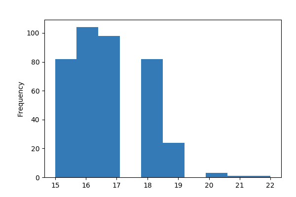

**Common Values**

| Value | Count | Frequency (%) |  |
| --- | --- | --- | --- |
| 16 | 104 | 26.3% |  |
| 17 | 98 | 24.8% |  |
| 18 | 82 | 20.8% |  |
| 15 | 82 | 20.8% |  |
| 19 | 24 | 6.1% |  |
| 20 | 3 | 0.8% |  |
| 22 | 1 | 0.3% |  |
| 21 | 1 | 0.3% |  |

**Extreme Values**

Minimum 5 values

| Value | Count | Frequency (%) |  |
| --- | --- | --- | --- |
| 15 | 82 | 20.8% |  |
| 16 | 104 | 26.3% |  |
| 17 | 98 | 24.8% |  |
| 18 | 82 | 20.8% |  |
| 19 | 24 | 6.1% |  |

Maximum 5 values

| Value | Count | Frequency (%) |  |
| --- | --- | --- | --- |
| 18 | 82 | 20.8% |  |
| 19 | 24 | 6.1% |  |
| 20 | 3 | 0.8% |  |
| 21 | 1 | 0.3% |  |
| 22 | 1 | 0.3% |  |

failures  
Numeric

| Distinct count | 4 |
| --- | --- |
| Unique (%) | 1.0% |
| Missing (%) | 0.0% |
| Missing (n) | 0 |
| Infinite (%) | 0.0% |
| Infinite (n) | 0 |

| Mean | 0.33418 |
| --- | --- |
| Minimum | 0 |
| Maximum | 3 |
| Zeros (%) | 79.0% |

Toggle details

**Statistics**

Quantile statistics

| Minimum | 0 |
| --- | --- |
| 5-th percentile | 0 |
| Q1 | 0 |
| Median | 0 |
| Q3 | 0 |
| 95-th percentile | 2 |
| Maximum | 3 |
| Range | 3 |
| Interquartile range | 0 |

Descriptive statistics

| Standard deviation | 0.74365 |
| --- | --- |
| Coef of variation | 2.2253 |
| Kurtosis | 5.0047 |
| Mean | 0.33418 |
| MAD | 0.52792 |
| Skewness | 2.387 |
| Sum | 132 |
| Variance | 0.55302 |
| Memory size | 3.2 KiB |

**Histogram**

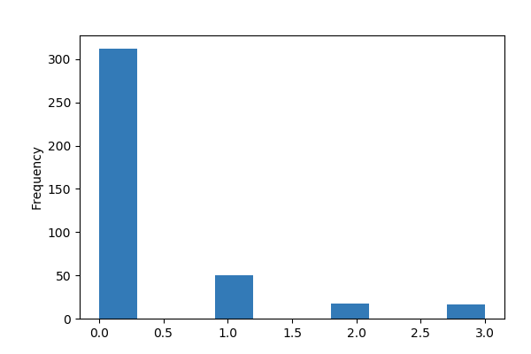

**Common Values**

| Value | Count | Frequency (%) |  |
| --- | --- | --- | --- |
| 0 | 312 | 79.0% |  |
| 1 | 50 | 12.7% |  |
| 2 | 17 | 4.3% |  |
| 3 | 16 | 4.1% |  |

**Extreme Values**

Minimum 5 values

| Value | Count | Frequency (%) |  |
| --- | --- | --- | --- |
| 0 | 312 | 79.0% |  |
| 1 | 50 | 12.7% |  |
| 2 | 17 | 4.3% |  |
| 3 | 16 | 4.1% |  |

Maximum 5 values

| Value | Count | Frequency (%) |  |
| --- | --- | --- | --- |
| 0 | 312 | 79.0% |  |
| 1 | 50 | 12.7% |  |
| 2 | 17 | 4.3% |  |
| 3 | 16 | 4.1% |  |

famrel  
Numeric

| Distinct count | 5 |
| --- | --- |
| Unique (%) | 1.3% |
| Missing (%) | 0.0% |
| Missing (n) | 0 |
| Infinite (%) | 0.0% |
| Infinite (n) | 0 |

| Mean | 3.9443 |
| --- | --- |
| Minimum | 1 |
| Maximum | 5 |
| Zeros (%) | 0.0% |

Toggle details

**Statistics**

Quantile statistics

| Minimum | 1 |
| --- | --- |
| 5-th percentile | 2 |
| Q1 | 4 |
| Median | 4 |
| Q3 | 5 |
| 95-th percentile | 5 |
| Maximum | 5 |
| Range | 4 |
| Interquartile range | 1 |

Descriptive statistics

| Standard deviation | 0.89666 |
| --- | --- |
| Coef of variation | 0.22733 |
| Kurtosis | 1.1398 |
| Mean | 3.9443 |
| MAD | 0.62159 |
| Skewness | -0.95188 |
| Sum | 1558 |
| Variance | 0.804 |
| Memory size | 3.2 KiB |

**Histogram**

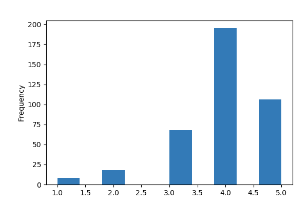

**Common Values**

| Value | Count | Frequency (%) |  |
| --- | --- | --- | --- |
| 4 | 195 | 49.4% |  |
| 5 | 106 | 26.8% |  |
| 3 | 68 | 17.2% |  |
| 2 | 18 | 4.6% |  |
| 1 | 8 | 2.0% |  |

**Extreme Values**

Minimum 5 values

| Value | Count | Frequency (%) |  |
| --- | --- | --- | --- |
| 1 | 8 | 2.0% |  |
| 2 | 18 | 4.6% |  |
| 3 | 68 | 17.2% |  |
| 4 | 195 | 49.4% |  |
| 5 | 106 | 26.8% |  |

Maximum 5 values

| Value | Count | Frequency (%) |  |
| --- | --- | --- | --- |
| 1 | 8 | 2.0% |  |
| 2 | 18 | 4.6% |  |
| 3 | 68 | 17.2% |  |
| 4 | 195 | 49.4% |  |
| 5 | 106 | 26.8% |  |

famsize  
Categorical

| Distinct count | 2 |
| --- | --- |
| Unique (%) | 0.5% |
| Missing (%) | 0.0% |
| Missing (n) | 0 |

| GT3 | 281 |
| --- | --- |
| LE3 | 114 |

Toggle details

| Value | Count | Frequency (%) |  |
| --- | --- | --- | --- |
| GT3 | 281 | 71.1% |  |
| LE3 | 114 | 28.9% |  |

famsup  
Categorical

| Distinct count | 2 |
| --- | --- |
| Unique (%) | 0.5% |
| Missing (%) | 0.0% |
| Missing (n) | 0 |

| yes | 242 |
| --- | --- |
| no | 153 |

Toggle details

| Value | Count | Frequency (%) |  |
| --- | --- | --- | --- |
| yes | 242 | 61.3% |  |
| no | 153 | 38.7% |  |

freetime  
Numeric

| Distinct count | 5 |
| --- | --- |
| Unique (%) | 1.3% |
| Missing (%) | 0.0% |
| Missing (n) | 0 |
| Infinite (%) | 0.0% |
| Infinite (n) | 0 |

| Mean | 3.2354 |
| --- | --- |
| Minimum | 1 |
| Maximum | 5 |
| Zeros (%) | 0.0% |

Toggle details

**Statistics**

Quantile statistics

| Minimum | 1 |
| --- | --- |
| 5-th percentile | 2 |
| Q1 | 3 |
| Median | 3 |
| Q3 | 4 |
| 95-th percentile | 5 |
| Maximum | 5 |
| Range | 4 |
| Interquartile range | 1 |

Descriptive statistics

| Standard deviation | 0.99886 |
| --- | --- |
| Coef of variation | 0.30872 |
| Kurtosis | -0.30181 |
| Mean | 3.2354 |
| MAD | 0.80256 |
| Skewness | -0.16335 |
| Sum | 1278 |
| Variance | 0.99773 |
| Memory size | 3.2 KiB |

**Histogram**

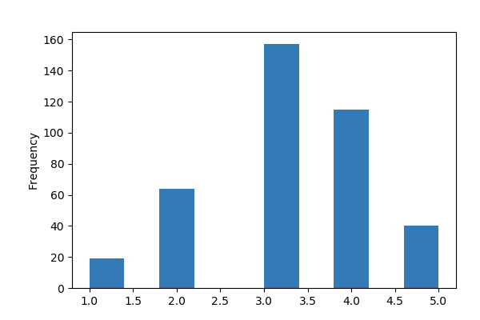

**Common Values**

| Value | Count | Frequency (%) |  |
| --- | --- | --- | --- |
| 3 | 157 | 39.7% |  |
| 4 | 115 | 29.1% |  |
| 2 | 64 | 16.2% |  |
| 5 | 40 | 10.1% |  |
| 1 | 19 | 4.8% |  |

**Extreme Values**

Minimum 5 values

| Value | Count | Frequency (%) |  |
| --- | --- | --- | --- |
| 1 | 19 | 4.8% |  |
| 2 | 64 | 16.2% |  |
| 3 | 157 | 39.7% |  |
| 4 | 115 | 29.1% |  |
| 5 | 40 | 10.1% |  |

Maximum 5 values

| Value | Count | Frequency (%) |  |
| --- | --- | --- | --- |
| 1 | 19 | 4.8% |  |
| 2 | 64 | 16.2% |  |
| 3 | 157 | 39.7% |  |
| 4 | 115 | 29.1% |  |
| 5 | 40 | 10.1% |  |

goout  
Numeric

| Distinct count | 5 |
| --- | --- |
| Unique (%) | 1.3% |
| Missing (%) | 0.0% |
| Missing (n) | 0 |
| Infinite (%) | 0.0% |
| Infinite (n) | 0 |

| Mean | 3.1089 |
| --- | --- |
| Minimum | 1 |
| Maximum | 5 |
| Zeros (%) | 0.0% |

Toggle details

**Statistics**

Quantile statistics

| Minimum | 1 |
| --- | --- |
| 5-th percentile | 1 |
| Q1 | 2 |
| Median | 3 |
| Q3 | 4 |
| 95-th percentile | 5 |
| Maximum | 5 |
| Range | 4 |
| Interquartile range | 2 |

Descriptive statistics

| Standard deviation | 1.1133 |
| --- | --- |
| Coef of variation | 0.3581 |
| Kurtosis | -0.77025 |
| Mean | 3.1089 |
| MAD | 0.89554 |
| Skewness | 0.1165 |
| Sum | 1228 |
| Variance | 1.2394 |
| Memory size | 3.2 KiB |

**Histogram**

[6 more figures not shown]

Sample

|  | school | sex | age | address | famsize | Pstatus | Medu | Fedu | Mjob | Fjob | reason | guardian | traveltime | studytime | failures | schoolsup | famsup | paid | activities | nursery | higher | internet | romantic | famrel | freetime | goout | Dalc | Walc | health | … |
| --- | --- | --- | --- | --- | --- | --- | --- | --- | --- | --- | --- | --- | --- | --- | --- | --- | --- | --- | --- | --- | --- | --- | --- | --- | --- | --- | --- | --- | --- | --- |
| 0 | GP | F | 18 | U | GT3 | A | 4 | 4 | at_home | teacher | course | mother | 2 | 2 | 0 | yes | no | no | no | yes | yes | no | no | 4 | 3 | 4 | 1 | 1 | 3 | … |
| 1 | GP | F | 17 | U | GT3 | T | 1 | 1 | at_home | other | course | father | 1 | 2 | 0 | no | yes | no | no | no | yes | yes | no | 5 | 3 | 3 | 1 | 1 | 3 | … |
| 2 | GP | F | 15 | U | LE3 | T | 1 | 1 | at_home | other | other | mother | 1 | 2 | 3 | yes | no | yes | no | yes | yes | yes | no | 4 | 3 | 2 | 2 | 3 | 3 | … |
| 3 | GP | F | 15 | U | GT3 | T | 4 | 2 | health | services | home | mother | 1 | 3 | 0 | no | yes | yes | yes | yes | yes | yes | yes | 3 | 2 | 2 | 1 | 1 | 5 | … |
| 4 | GP | F | 16 | U | GT3 | T | 3 | 3 | other | other | home | father | 1 | 2 | 0 | no | yes | yes | no | yes | yes | no | no | 4 | 3 | 2 | 1 | 2 | 5 | … |

```python
#Estadicas por variable
pandas_profiling.ProfileReport(df)
```

```python
df.head()
```

|  | school | sex | age | address | famsize | Pstatus | Medu | Fedu | Mjob | Fjob | ... | freetime | goout | Dalc | Walc | health | absences | G1 | G2 | G3 | Alc |
| --- | --- | --- | --- | --- | --- | --- | --- | --- | --- | --- | --- | --- | --- | --- | --- | --- | --- | --- | --- | --- | --- |
| 0 | GP | F | 18 | U | GT3 | A | 4 | 4 | at_home | teacher | ... | 3 | 4 | 1 | 1 | 3 | 6 | 5 | 6 | 6 | 1 |
| 1 | GP | F | 17 | U | GT3 | T | 1 | 1 | at_home | other | ... | 3 | 3 | 1 | 1 | 3 | 4 | 5 | 5 | 6 | 1 |
| 2 | GP | F | 15 | U | LE3 | T | 1 | 1 | at_home | other | ... | 3 | 2 | 2 | 3 | 3 | 10 | 7 | 8 | 10 | 2 |
| 3 | GP | F | 15 | U | GT3 | T | 4 | 2 | health | services | ... | 2 | 2 | 1 | 1 | 5 | 2 | 15 | 14 | 15 | 1 |
| 4 | GP | F | 16 | U | GT3 | T | 3 | 3 | other | other | ... | 3 | 2 | 1 | 2 | 5 | 4 | 6 | 10 | 10 | 1 |

5 rows × 34 columns

### Crear la etiqueta de clase

```python
df_full = df.copy()
```

```python
df_full["Drink"] = np.where(df_full['Alc']<3, 0,1)
df_full.head()
```

|  | school | sex | age | address | famsize | Pstatus | Medu | Fedu | Mjob | Fjob | ... | goout | Dalc | Walc | health | absences | G1 | G2 | G3 | Alc | Drink |
| --- | --- | --- | --- | --- | --- | --- | --- | --- | --- | --- | --- | --- | --- | --- | --- | --- | --- | --- | --- | --- | --- |
| 0 | GP | F | 18 | U | GT3 | A | 4 | 4 | at_home | teacher | ... | 4 | 1 | 1 | 3 | 6 | 5 | 6 | 6 | 1 | 0 |
| 1 | GP | F | 17 | U | GT3 | T | 1 | 1 | at_home | other | ... | 3 | 1 | 1 | 3 | 4 | 5 | 5 | 6 | 1 | 0 |
| 2 | GP | F | 15 | U | LE3 | T | 1 | 1 | at_home | other | ... | 2 | 2 | 3 | 3 | 10 | 7 | 8 | 10 | 2 | 0 |
| 3 | GP | F | 15 | U | GT3 | T | 4 | 2 | health | services | ... | 2 | 1 | 1 | 5 | 2 | 15 | 14 | 15 | 1 | 0 |
| 4 | GP | F | 16 | U | GT3 | T | 3 | 3 | other | other | ... | 2 | 1 | 2 | 5 | 4 | 6 | 10 | 10 | 1 | 0 |

5 rows × 35 columns

```python
#eliminar alc parece ser la clase, y generar un var nuevo promedio de g1, g2, g3
```

```python
## Se eliman el atributo clase alc
df= df.drop(['Alc'], axis=1)
df.head()
```

|  | school | sex | age | address | famsize | Pstatus | Medu | Fedu | Mjob | Fjob | ... | famrel | freetime | goout | Dalc | Walc | health | absences | G1 | G2 | G3 |
| --- | --- | --- | --- | --- | --- | --- | --- | --- | --- | --- | --- | --- | --- | --- | --- | --- | --- | --- | --- | --- | --- |
| 0 | GP | F | 18 | U | GT3 | A | 4 | 4 | at_home | teacher | ... | 4 | 3 | 4 | 1 | 1 | 3 | 6 | 5 | 6 | 6 |
| 1 | GP | F | 17 | U | GT3 | T | 1 | 1 | at_home | other | ... | 5 | 3 | 3 | 1 | 1 | 3 | 4 | 5 | 5 | 6 |
| 2 | GP | F | 15 | U | LE3 | T | 1 | 1 | at_home | other | ... | 4 | 3 | 2 | 2 | 3 | 3 | 10 | 7 | 8 | 10 |
| 3 | GP | F | 15 | U | GT3 | T | 4 | 2 | health | services | ... | 3 | 2 | 2 | 1 | 1 | 5 | 2 | 15 | 14 | 15 |
| 4 | GP | F | 16 | U | GT3 | T | 3 | 3 | other | other | ... | 4 | 3 | 2 | 1 | 2 | 5 | 4 | 6 | 10 | 10 |

5 rows × 33 columns

```python
# se crea 'Avg' atributo con la media de las notas de los grados G1,G2,G3, por estar altamente correlacionas
df['Avg'] = df[['G1', 'G2','G3']].mean(axis=1)
df.head()
```

|  | school | sex | age | address | famsize | Pstatus | Medu | Fedu | Mjob | Fjob | ... | freetime | goout | Dalc | Walc | health | absences | G1 | G2 | G3 | Avg |
| --- | --- | --- | --- | --- | --- | --- | --- | --- | --- | --- | --- | --- | --- | --- | --- | --- | --- | --- | --- | --- | --- |
| 0 | GP | F | 18 | U | GT3 | A | 4 | 4 | at_home | teacher | ... | 3 | 4 | 1 | 1 | 3 | 6 | 5 | 6 | 6 | 5.666667 |
| 1 | GP | F | 17 | U | GT3 | T | 1 | 1 | at_home | other | ... | 3 | 3 | 1 | 1 | 3 | 4 | 5 | 5 | 6 | 5.333333 |
| 2 | GP | F | 15 | U | LE3 | T | 1 | 1 | at_home | other | ... | 3 | 2 | 2 | 3 | 3 | 10 | 7 | 8 | 10 | 8.333333 |
| 3 | GP | F | 15 | U | GT3 | T | 4 | 2 | health | services | ... | 2 | 2 | 1 | 1 | 5 | 2 | 15 | 14 | 15 | 14.666667 |
| 4 | GP | F | 16 | U | GT3 | T | 3 | 3 | other | other | ... | 3 | 2 | 1 | 2 | 5 | 4 | 6 | 10 | 10 | 8.666667 |

5 rows × 34 columns

```python
df['Avg'] =df.Avg.round(decimals=1)
df.head()
```

|  | school | sex | age | address | famsize | Pstatus | Medu | Fedu | Mjob | Fjob | ... | freetime | goout | Dalc | Walc | health | absences | G1 | G2 | G3 | Avg |
| --- | --- | --- | --- | --- | --- | --- | --- | --- | --- | --- | --- | --- | --- | --- | --- | --- | --- | --- | --- | --- | --- |
| 0 | GP | F | 18 | U | GT3 | A | 4 | 4 | at_home | teacher | ... | 3 | 4 | 1 | 1 | 3 | 6 | 5 | 6 | 6 | 5.7 |
| 1 | GP | F | 17 | U | GT3 | T | 1 | 1 | at_home | other | ... | 3 | 3 | 1 | 1 | 3 | 4 | 5 | 5 | 6 | 5.3 |
| 2 | GP | F | 15 | U | LE3 | T | 1 | 1 | at_home | other | ... | 3 | 2 | 2 | 3 | 3 | 10 | 7 | 8 | 10 | 8.3 |
| 3 | GP | F | 15 | U | GT3 | T | 4 | 2 | health | services | ... | 2 | 2 | 1 | 1 | 5 | 2 | 15 | 14 | 15 | 14.7 |
| 4 | GP | F | 16 | U | GT3 | T | 3 | 3 | other | other | ... | 3 | 2 | 1 | 2 | 5 | 4 | 6 | 10 | 10 | 8.7 |

5 rows × 34 columns

```python
## Se eliman el atributo clase G1,G2,G2
df= df.drop(['G1','G2','G3'], axis=1)
df.head()
```

|  | school | sex | age | address | famsize | Pstatus | Medu | Fedu | Mjob | Fjob | ... | internet | romantic | famrel | freetime | goout | Dalc | Walc | health | absences | Avg |
| --- | --- | --- | --- | --- | --- | --- | --- | --- | --- | --- | --- | --- | --- | --- | --- | --- | --- | --- | --- | --- | --- |
| 0 | GP | F | 18 | U | GT3 | A | 4 | 4 | at_home | teacher | ... | no | no | 4 | 3 | 4 | 1 | 1 | 3 | 6 | 5.7 |
| 1 | GP | F | 17 | U | GT3 | T | 1 | 1 | at_home | other | ... | yes | no | 5 | 3 | 3 | 1 | 1 | 3 | 4 | 5.3 |
| 2 | GP | F | 15 | U | LE3 | T | 1 | 1 | at_home | other | ... | yes | no | 4 | 3 | 2 | 2 | 3 | 3 | 10 | 8.3 |
| 3 | GP | F | 15 | U | GT3 | T | 4 | 2 | health | services | ... | yes | yes | 3 | 2 | 2 | 1 | 1 | 5 | 2 | 14.7 |
| 4 | GP | F | 16 | U | GT3 | T | 3 | 3 | other | other | ... | no | no | 4 | 3 | 2 | 1 | 2 | 5 | 4 | 8.7 |

5 rows × 31 columns

```python
df_full.head()
```

|  | school | sex | age | address | famsize | Pstatus | Medu | Fedu | Mjob | Fjob | ... | goout | Dalc | Walc | health | absences | G1 | G2 | G3 | Alc | Drink |
| --- | --- | --- | --- | --- | --- | --- | --- | --- | --- | --- | --- | --- | --- | --- | --- | --- | --- | --- | --- | --- | --- |
| 0 | GP | F | 18 | U | GT3 | A | 4 | 4 | at_home | teacher | ... | 4 | 1 | 1 | 3 | 6 | 5 | 6 | 6 | 1 | 0 |
| 1 | GP | F | 17 | U | GT3 | T | 1 | 1 | at_home | other | ... | 3 | 1 | 1 | 3 | 4 | 5 | 5 | 6 | 1 | 0 |
| 2 | GP | F | 15 | U | LE3 | T | 1 | 1 | at_home | other | ... | 2 | 2 | 3 | 3 | 10 | 7 | 8 | 10 | 2 | 0 |
| 3 | GP | F | 15 | U | GT3 | T | 4 | 2 | health | services | ... | 2 | 1 | 1 | 5 | 2 | 15 | 14 | 15 | 1 | 0 |
| 4 | GP | F | 16 | U | GT3 | T | 3 | 3 | other | other | ... | 2 | 1 | 2 | 5 | 4 | 6 | 10 | 10 | 1 | 0 |

5 rows × 35 columns

## NUMERIZAR VARIABLES

#Numerizar variables #school, sex,adress,famsize,Pstatus,Mjob,Fjob, reason,guardian,schoolsup, famsup, paid,activities, nursery, higher,intenert,romantic

```python
#Numerizar varibles object
for c in df.columns:
        if df[c].dtype == 'object':
            lbl = preprocessing.LabelEncoder()
            lbl.fit(list(df[c].values))
            df[c] = lbl.transform(list(df[c].values))
```

```python
df.head()
```

|  | school | sex | age | address | famsize | Pstatus | Medu | Fedu | Mjob | Fjob | ... | internet | romantic | famrel | freetime | goout | Dalc | Walc | health | absences | Avg |
| --- | --- | --- | --- | --- | --- | --- | --- | --- | --- | --- | --- | --- | --- | --- | --- | --- | --- | --- | --- | --- | --- |
| 0 | 0 | 0 | 18 | 1 | 0 | 0 | 4 | 4 | 0 | 4 | ... | 0 | 0 | 4 | 3 | 4 | 1 | 1 | 3 | 6 | 5.7 |
| 1 | 0 | 0 | 17 | 1 | 0 | 1 | 1 | 1 | 0 | 2 | ... | 1 | 0 | 5 | 3 | 3 | 1 | 1 | 3 | 4 | 5.3 |
| 2 | 0 | 0 | 15 | 1 | 1 | 1 | 1 | 1 | 0 | 2 | ... | 1 | 0 | 4 | 3 | 2 | 2 | 3 | 3 | 10 | 8.3 |
| 3 | 0 | 0 | 15 | 1 | 0 | 1 | 4 | 2 | 1 | 3 | ... | 1 | 1 | 3 | 2 | 2 | 1 | 1 | 5 | 2 | 14.7 |
| 4 | 0 | 0 | 16 | 1 | 0 | 1 | 3 | 3 | 2 | 2 | ... | 0 | 0 | 4 | 3 | 2 | 1 | 2 | 5 | 4 | 8.7 |

5 rows × 31 columns

Overview

Dataset info

| Number of variables | 31 |
| --- | --- |
| Number of observations | 395 |
| Total Missing (%) | 0.0% |
| Total size in memory | 95.7 KiB |
| Average record size in memory | 248.2 B |

Variables types

| Numeric | 18 |
| --- | --- |
| Categorical | 0 |
| Boolean | 13 |
| Date | 0 |
| Text (Unique) | 0 |
| Rejected | 0 |
| Unsupported | 0 |

Warnings

- `Fjob` has 20 / 5.1% zeros Zeros

- `Mjob` has 59 / 14.9% zeros Zeros

- `absences` has 115 / 29.1% zeros Zeros

- `failures` has 312 / 79.0% zeros Zeros

- `guardian` has 90 / 22.8% zeros Zeros

- `reason` has 145 / 36.7% zeros Zeros

Variables

Avg  
Numeric

| Distinct count | 54 |
| --- | --- |
| Unique (%) | 13.7% |
| Missing (%) | 0.0% |
| Missing (n) | 0 |
| Infinite (%) | 0.0% |
| Infinite (n) | 0 |

| Mean | 10.677 |
| --- | --- |
| Minimum | 1.3 |
| Maximum | 19.3 |
| Zeros (%) | 0.0% |

Toggle details

**Statistics**

Quantile statistics

| Minimum | 1.3 |
| --- | --- |
| 5-th percentile | 4.21 |
| Q1 | 8.3 |
| Median | 10.7 |
| Q3 | 13.3 |
| 95-th percentile | 16.7 |
| Maximum | 19.3 |
| Range | 18 |
| Interquartile range | 5 |

Descriptive statistics

| Standard deviation | 3.6981 |
| --- | --- |
| Coef of variation | 0.34635 |
| Kurtosis | -0.33463 |
| Mean | 10.677 |
| MAD | 2.9789 |
| Skewness | -0.14022 |
| Sum | 4217.6 |
| Variance | 13.676 |
| Memory size | 3.2 KiB |

**Histogram**

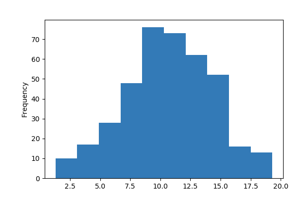

**Common Values**

| Value | Count | Frequency (%) |  |
| --- | --- | --- | --- |
| 9.0 | 23 | 5.8% |  |
| 9.3 | 21 | 5.3% |  |
| 12.3 | 16 | 4.1% |  |
| 10.0 | 15 | 3.8% |  |
| 10.7 | 14 | 3.5% |  |
| 11.7 | 14 | 3.5% |  |
| 11.0 | 13 | 3.3% |  |
| 11.3 | 13 | 3.3% |  |
| 12.7 | 13 | 3.3% |  |
| 15.3 | 13 | 3.3% |  |
| Other values (44) | 240 | 60.8% |  |

**Extreme Values**

Minimum 5 values

| Value | Count | Frequency (%) |  |
| --- | --- | --- | --- |
| 1.3 | 1 | 0.3% |  |
| 1.7 | 2 | 0.5% |  |
| 2.0 | 2 | 0.5% |  |
| 2.3 | 3 | 0.8% |  |
| 2.7 | 1 | 0.3% |  |

Maximum 5 values

| Value | Count | Frequency (%) |  |
| --- | --- | --- | --- |
| 17.7 | 3 | 0.8% |  |
| 18.0 | 4 | 1.0% |  |
| 18.3 | 2 | 0.5% |  |
| 18.7 | 3 | 0.8% |  |
| 19.3 | 1 | 0.3% |  |

Dalc  
Numeric

| Distinct count | 5 |
| --- | --- |
| Unique (%) | 1.3% |
| Missing (%) | 0.0% |
| Missing (n) | 0 |
| Infinite (%) | 0.0% |
| Infinite (n) | 0 |

| Mean | 1.481 |
| --- | --- |
| Minimum | 1 |
| Maximum | 5 |
| Zeros (%) | 0.0% |

Toggle details

**Statistics**

Quantile statistics

| Minimum | 1 |
| --- | --- |
| 5-th percentile | 1 |
| Q1 | 1 |
| Median | 1 |
| Q3 | 2 |
| 95-th percentile | 3 |
| Maximum | 5 |
| Range | 4 |
| Interquartile range | 1 |

Descriptive statistics

| Standard deviation | 0.89074 |
| --- | --- |
| Coef of variation | 0.60144 |
| Kurtosis | 4.7595 |
| Mean | 1.481 |
| MAD | 0.6722 |
| Skewness | 2.1908 |
| Sum | 585 |
| Variance | 0.79342 |
| Memory size | 3.2 KiB |

**Histogram**

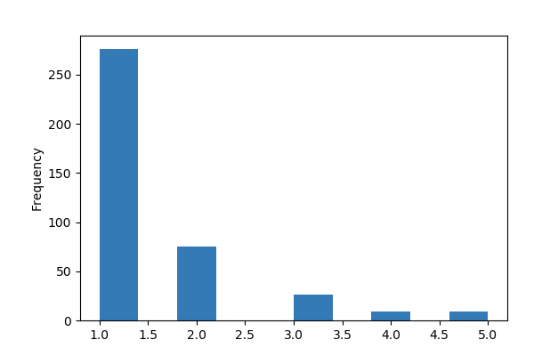

**Common Values**

| Value | Count | Frequency (%) |  |
| --- | --- | --- | --- |
| 1 | 276 | 69.9% |  |
| 2 | 75 | 19.0% |  |
| 3 | 26 | 6.6% |  |
| 5 | 9 | 2.3% |  |
| 4 | 9 | 2.3% |  |

**Extreme Values**

Minimum 5 values

| Value | Count | Frequency (%) |  |
| --- | --- | --- | --- |
| 1 | 276 | 69.9% |  |
| 2 | 75 | 19.0% |  |
| 3 | 26 | 6.6% |  |
| 4 | 9 | 2.3% |  |
| 5 | 9 | 2.3% |  |

Maximum 5 values

| Value | Count | Frequency (%) |  |
| --- | --- | --- | --- |
| 1 | 276 | 69.9% |  |
| 2 | 75 | 19.0% |  |
| 3 | 26 | 6.6% |  |
| 4 | 9 | 2.3% |  |
| 5 | 9 | 2.3% |  |

Fedu  
Numeric

| Distinct count | 5 |
| --- | --- |
| Unique (%) | 1.3% |
| Missing (%) | 0.0% |
| Missing (n) | 0 |
| Infinite (%) | 0.0% |
| Infinite (n) | 0 |

| Mean | 2.5215 |
| --- | --- |
| Minimum | 0 |
| Maximum | 4 |
| Zeros (%) | 0.5% |

Toggle details

**Statistics**

Quantile statistics

| Minimum | 0 |
| --- | --- |
| 5-th percentile | 1 |
| Q1 | 2 |
| Median | 2 |
| Q3 | 3 |
| 95-th percentile | 4 |
| Maximum | 4 |
| Range | 4 |
| Interquartile range | 1 |

Descriptive statistics

| Standard deviation | 1.0882 |
| --- | --- |
| Coef of variation | 0.43157 |
| Kurtosis | -1.1985 |
| Mean | 2.5215 |
| MAD | 0.96092 |
| Skewness | -0.031672 |
| Sum | 996 |
| Variance | 1.1842 |
| Memory size | 3.2 KiB |

**Histogram**

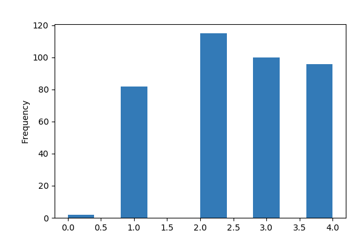

**Common Values**

| Value | Count | Frequency (%) |  |
| --- | --- | --- | --- |
| 2 | 115 | 29.1% |  |
| 3 | 100 | 25.3% |  |
| 4 | 96 | 24.3% |  |
| 1 | 82 | 20.8% |  |
| 0 | 2 | 0.5% |  |

**Extreme Values**

Minimum 5 values

| Value | Count | Frequency (%) |  |
| --- | --- | --- | --- |
| 0 | 2 | 0.5% |  |
| 1 | 82 | 20.8% |  |
| 2 | 115 | 29.1% |  |
| 3 | 100 | 25.3% |  |
| 4 | 96 | 24.3% |  |

Maximum 5 values

| Value | Count | Frequency (%) |  |
| --- | --- | --- | --- |
| 0 | 2 | 0.5% |  |
| 1 | 82 | 20.8% |  |
| 2 | 115 | 29.1% |  |
| 3 | 100 | 25.3% |  |
| 4 | 96 | 24.3% |  |

Fjob  
Numeric

| Distinct count | 5 |
| --- | --- |
| Unique (%) | 1.3% |
| Missing (%) | 0.0% |
| Missing (n) | 0 |
| Infinite (%) | 0.0% |
| Infinite (n) | 0 |

| Mean | 2.281 |
| --- | --- |
| Minimum | 0 |
| Maximum | 4 |
| Zeros (%) | 5.1% |

Toggle details

**Statistics**

Quantile statistics

| Minimum | 0 |
| --- | --- |
| 5-th percentile | 0.7 |
| Q1 | 2 |
| Median | 2 |
| Q3 | 3 |
| 95-th percentile | 4 |
| Maximum | 4 |
| Range | 4 |
| Interquartile range | 1 |

Descriptive statistics

| Standard deviation | 0.86354 |
| --- | --- |
| Coef of variation | 0.37858 |
| Kurtosis | 1.028 |
| Mean | 2.281 |
| MAD | 0.6565 |
| Skewness | -0.3623 |
| Sum | 901 |
| Variance | 0.7457 |
| Memory size | 3.2 KiB |

**Histogram**

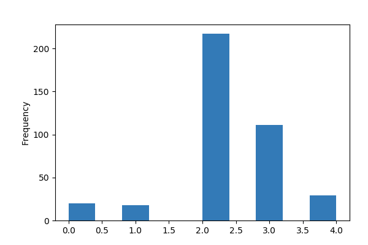

**Common Values**

| Value | Count | Frequency (%) |  |
| --- | --- | --- | --- |
| 2 | 217 | 54.9% |  |
| 3 | 111 | 28.1% |  |
| 4 | 29 | 7.3% |  |
| 0 | 20 | 5.1% |  |
| 1 | 18 | 4.6% |  |

**Extreme Values**

Minimum 5 values

| Value | Count | Frequency (%) |  |
| --- | --- | --- | --- |
| 0 | 20 | 5.1% |  |
| 1 | 18 | 4.6% |  |
| 2 | 217 | 54.9% |  |
| 3 | 111 | 28.1% |  |
| 4 | 29 | 7.3% |  |

Maximum 5 values

| Value | Count | Frequency (%) |  |
| --- | --- | --- | --- |
| 0 | 20 | 5.1% |  |
| 1 | 18 | 4.6% |  |
| 2 | 217 | 54.9% |  |
| 3 | 111 | 28.1% |  |
| 4 | 29 | 7.3% |  |

Medu  
Numeric

| Distinct count | 5 |
| --- | --- |
| Unique (%) | 1.3% |
| Missing (%) | 0.0% |
| Missing (n) | 0 |
| Infinite (%) | 0.0% |
| Infinite (n) | 0 |

| Mean | 2.7494 |
| --- | --- |
| Minimum | 0 |
| Maximum | 4 |
| Zeros (%) | 0.8% |

Toggle details

**Statistics**

Quantile statistics

| Minimum | 0 |
| --- | --- |
| 5-th percentile | 1 |
| Q1 | 2 |
| Median | 3 |
| Q3 | 4 |
| 95-th percentile | 4 |
| Maximum | 4 |
| Range | 4 |
| Interquartile range | 2 |

Descriptive statistics

| Standard deviation | 1.0947 |
| --- | --- |
| Coef of variation | 0.39818 |
| Kurtosis | -1.09 |
| Mean | 2.7494 |
| MAD | 0.95517 |
| Skewness | -0.31838 |
| Sum | 1086 |
| Variance | 1.1984 |
| Memory size | 3.2 KiB |

**Histogram**

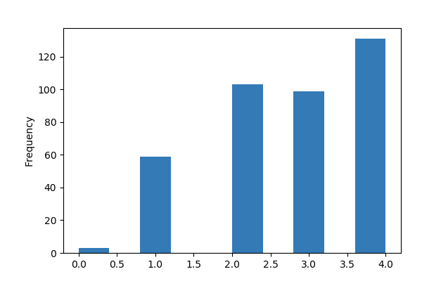

**Common Values**

| Value | Count | Frequency (%) |  |
| --- | --- | --- | --- |
| 4 | 131 | 33.2% |  |
| 2 | 103 | 26.1% |  |
| 3 | 99 | 25.1% |  |
| 1 | 59 | 14.9% |  |
| 0 | 3 | 0.8% |  |

**Extreme Values**

Minimum 5 values

| Value | Count | Frequency (%) |  |
| --- | --- | --- | --- |
| 0 | 3 | 0.8% |  |
| 1 | 59 | 14.9% |  |
| 2 | 103 | 26.1% |  |
| 3 | 99 | 25.1% |  |
| 4 | 131 | 33.2% |  |

Maximum 5 values

| Value | Count | Frequency (%) |  |
| --- | --- | --- | --- |
| 0 | 3 | 0.8% |  |
| 1 | 59 | 14.9% |  |
| 2 | 103 | 26.1% |  |
| 3 | 99 | 25.1% |  |
| 4 | 131 | 33.2% |  |

Mjob  
Numeric

| Distinct count | 5 |
| --- | --- |
| Unique (%) | 1.3% |
| Missing (%) | 0.0% |
| Missing (n) | 0 |
| Infinite (%) | 0.0% |
| Infinite (n) | 0 |

| Mean | 2.1696 |
| --- | --- |
| Minimum | 0 |
| Maximum | 4 |
| Zeros (%) | 14.9% |

Toggle details

**Statistics**

Quantile statistics

| Minimum | 0 |
| --- | --- |
| 5-th percentile | 0 |
| Q1 | 2 |
| Median | 2 |
| Q3 | 3 |
| 95-th percentile | 4 |
| Maximum | 4 |
| Range | 4 |
| Interquartile range | 1 |

Descriptive statistics

| Standard deviation | 1.2275 |
| --- | --- |
| Coef of variation | 0.56575 |
| Kurtosis | -0.67191 |
| Mean | 2.1696 |
| MAD | 0.97059 |
| Skewness | -0.33519 |
| Sum | 857 |
| Variance | 1.5067 |
| Memory size | 3.2 KiB |

**Histogram**

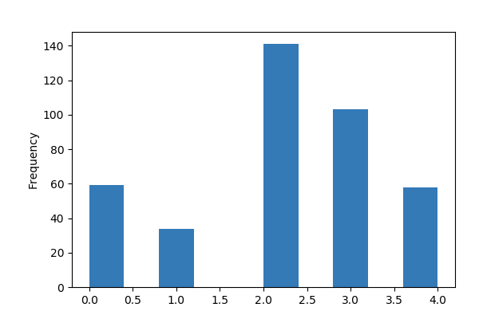

**Common Values**

| Value | Count | Frequency (%) |  |
| --- | --- | --- | --- |
| 2 | 141 | 35.7% |  |
| 3 | 103 | 26.1% |  |
| 0 | 59 | 14.9% |  |
| 4 | 58 | 14.7% |  |
| 1 | 34 | 8.6% |  |

**Extreme Values**

Minimum 5 values

| Value | Count | Frequency (%) |  |
| --- | --- | --- | --- |
| 0 | 59 | 14.9% |  |
| 1 | 34 | 8.6% |  |
| 2 | 141 | 35.7% |  |
| 3 | 103 | 26.1% |  |
| 4 | 58 | 14.7% |  |

Maximum 5 values

| Value | Count | Frequency (%) |  |
| --- | --- | --- | --- |
| 0 | 59 | 14.9% |  |
| 1 | 34 | 8.6% |  |
| 2 | 141 | 35.7% |  |
| 3 | 103 | 26.1% |  |
| 4 | 58 | 14.7% |  |

Pstatus  
Boolean

| Distinct count | 2 |
| --- | --- |
| Unique (%) | 0.5% |
| Missing (%) | 0.0% |
| Missing (n) | 0 |

| Mean | 0.8962 |
| --- | --- |

| 1 | 354 |
| --- | --- |
| 0 | 41 |

Toggle details

| Value | Count | Frequency (%) |  |
| --- | --- | --- | --- |
| 1 | 354 | 89.6% |  |
| 0 | 41 | 10.4% |  |

Walc  
Numeric

| Distinct count | 5 |
| --- | --- |
| Unique (%) | 1.3% |
| Missing (%) | 0.0% |
| Missing (n) | 0 |
| Infinite (%) | 0.0% |
| Infinite (n) | 0 |

| Mean | 2.2911 |
| --- | --- |
| Minimum | 1 |
| Maximum | 5 |
| Zeros (%) | 0.0% |

Toggle details

**Statistics**

Quantile statistics

| Minimum | 1 |
| --- | --- |
| 5-th percentile | 1 |
| Q1 | 1 |
| Median | 2 |
| Q3 | 3 |
| 95-th percentile | 5 |
| Maximum | 5 |
| Range | 4 |
| Interquartile range | 2 |

Descriptive statistics

| Standard deviation | 1.2879 |
| --- | --- |
| Coef of variation | 0.56212 |
| Kurtosis | -0.79085 |
| Mean | 2.2911 |
| MAD | 1.1124 |
| Skewness | 0.61196 |
| Sum | 905 |
| Variance | 1.6587 |
| Memory size | 3.2 KiB |

**Histogram**

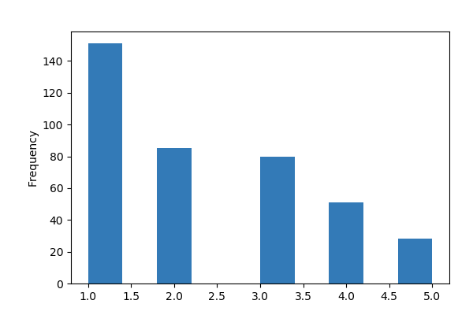

**Common Values**

| Value | Count | Frequency (%) |  |
| --- | --- | --- | --- |
| 1 | 151 | 38.2% |  |
| 2 | 85 | 21.5% |  |
| 3 | 80 | 20.3% |  |
| 4 | 51 | 12.9% |  |
| 5 | 28 | 7.1% |  |

**Extreme Values**

Minimum 5 values

| Value | Count | Frequency (%) |  |
| --- | --- | --- | --- |
| 1 | 151 | 38.2% |  |
| 2 | 85 | 21.5% |  |
| 3 | 80 | 20.3% |  |
| 4 | 51 | 12.9% |  |
| 5 | 28 | 7.1% |  |

Maximum 5 values

| Value | Count | Frequency (%) |  |
| --- | --- | --- | --- |
| 1 | 151 | 38.2% |  |
| 2 | 85 | 21.5% |  |
| 3 | 80 | 20.3% |  |
| 4 | 51 | 12.9% |  |
| 5 | 28 | 7.1% |  |

absences  
Numeric

| Distinct count | 34 |
| --- | --- |
| Unique (%) | 8.6% |
| Missing (%) | 0.0% |
| Missing (n) | 0 |
| Infinite (%) | 0.0% |
| Infinite (n) | 0 |

| Mean | 5.7089 |
| --- | --- |
| Minimum | 0 |
| Maximum | 75 |
| Zeros (%) | 29.1% |

Toggle details

**Statistics**

Quantile statistics

| Minimum | 0 |
| --- | --- |
| 5-th percentile | 0 |
| Q1 | 0 |
| Median | 4 |
| Q3 | 8 |
| 95-th percentile | 18.3 |
| Maximum | 75 |
| Range | 75 |
| Interquartile range | 8 |

Descriptive statistics

| Standard deviation | 8.0031 |
| --- | --- |
| Coef of variation | 1.4019 |
| Kurtosis | 21.719 |
| Mean | 5.7089 |
| MAD | 5.2026 |
| Skewness | 3.6716 |
| Sum | 2255 |
| Variance | 64.05 |
| Memory size | 3.2 KiB |

**Histogram**

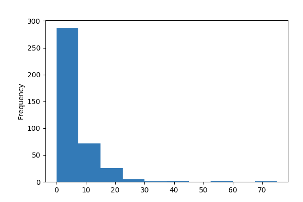

**Common Values**

| Value | Count | Frequency (%) |  |
| --- | --- | --- | --- |
| 0 | 115 | 29.1% |  |
| 2 | 65 | 16.5% |  |
| 4 | 53 | 13.4% |  |
| 6 | 31 | 7.8% |  |
| 8 | 22 | 5.6% |  |
| 10 | 17 | 4.3% |  |
| 14 | 12 | 3.0% |  |
| 12 | 12 | 3.0% |  |
| 3 | 8 | 2.0% |  |
| 7 | 7 | 1.8% |  |
| Other values (24) | 53 | 13.4% |  |

**Extreme Values**

Minimum 5 values

| Value | Count | Frequency (%) |  |
| --- | --- | --- | --- |
| 0 | 115 | 29.1% |  |
| 1 | 3 | 0.8% |  |
| 2 | 65 | 16.5% |  |
| 3 | 8 | 2.0% |  |
| 4 | 53 | 13.4% |  |

Maximum 5 values

| Value | Count | Frequency (%) |  |
| --- | --- | --- | --- |
| 38 | 1 | 0.3% |  |
| 40 | 1 | 0.3% |  |
| 54 | 1 | 0.3% |  |
| 56 | 1 | 0.3% |  |
| 75 | 1 | 0.3% |  |

activities  
Boolean

| Distinct count | 2 |
| --- | --- |
| Unique (%) | 0.5% |
| Missing (%) | 0.0% |
| Missing (n) | 0 |

| Mean | 0.50886 |
| --- | --- |

| 1 | 201 |
| --- | --- |
| 0 | 194 |

Toggle details

| Value | Count | Frequency (%) |  |
| --- | --- | --- | --- |
| 1 | 201 | 50.9% |  |
| 0 | 194 | 49.1% |  |

address  
Boolean

| Distinct count | 2 |
| --- | --- |
| Unique (%) | 0.5% |
| Missing (%) | 0.0% |
| Missing (n) | 0 |

| Mean | 0.77722 |
| --- | --- |

| 1 | 307 |
| --- | --- |
| 0 | 88 |

Toggle details

| Value | Count | Frequency (%) |  |
| --- | --- | --- | --- |
| 1 | 307 | 77.7% |  |
| 0 | 88 | 22.3% |  |

age  
Numeric

| Distinct count | 8 |
| --- | --- |
| Unique (%) | 2.0% |
| Missing (%) | 0.0% |
| Missing (n) | 0 |
| Infinite (%) | 0.0% |
| Infinite (n) | 0 |

| Mean | 16.696 |
| --- | --- |
| Minimum | 15 |
| Maximum | 22 |
| Zeros (%) | 0.0% |

Toggle details

**Statistics**

Quantile statistics

| Minimum | 15 |
| --- | --- |
| 5-th percentile | 15 |
| Q1 | 16 |
| Median | 17 |
| Q3 | 18 |
| 95-th percentile | 19 |
| Maximum | 22 |
| Range | 7 |
| Interquartile range | 2 |

Descriptive statistics

| Standard deviation | 1.276 |
| --- | --- |
| Coef of variation | 0.076427 |
| Kurtosis | -0.0012218 |
| Mean | 16.696 |
| MAD | 1.0709 |
| Skewness | 0.46627 |
| Sum | 6595 |
| Variance | 1.6283 |
| Memory size | 3.2 KiB |

**Histogram**

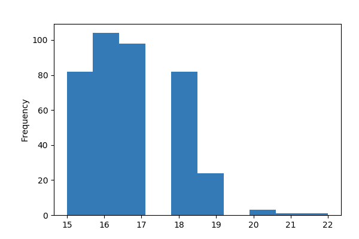

**Common Values**

| Value | Count | Frequency (%) |  |
| --- | --- | --- | --- |
| 16 | 104 | 26.3% |  |
| 17 | 98 | 24.8% |  |
| 18 | 82 | 20.8% |  |
| 15 | 82 | 20.8% |  |
| 19 | 24 | 6.1% |  |
| 20 | 3 | 0.8% |  |
| 22 | 1 | 0.3% |  |
| 21 | 1 | 0.3% |  |

**Extreme Values**

Minimum 5 values

| Value | Count | Frequency (%) |  |
| --- | --- | --- | --- |
| 15 | 82 | 20.8% |  |
| 16 | 104 | 26.3% |  |
| 17 | 98 | 24.8% |  |
| 18 | 82 | 20.8% |  |
| 19 | 24 | 6.1% |  |

Maximum 5 values

| Value | Count | Frequency (%) |  |
| --- | --- | --- | --- |
| 18 | 82 | 20.8% |  |
| 19 | 24 | 6.1% |  |
| 20 | 3 | 0.8% |  |
| 21 | 1 | 0.3% |  |
| 22 | 1 | 0.3% |  |

failures  
Numeric

| Distinct count | 4 |
| --- | --- |
| Unique (%) | 1.0% |
| Missing (%) | 0.0% |
| Missing (n) | 0 |
| Infinite (%) | 0.0% |
| Infinite (n) | 0 |

| Mean | 0.33418 |
| --- | --- |
| Minimum | 0 |
| Maximum | 3 |
| Zeros (%) | 79.0% |

Toggle details

**Statistics**

Quantile statistics

| Minimum | 0 |
| --- | --- |
| 5-th percentile | 0 |
| Q1 | 0 |
| Median | 0 |
| Q3 | 0 |
| 95-th percentile | 2 |
| Maximum | 3 |
| Range | 3 |
| Interquartile range | 0 |

Descriptive statistics

| Standard deviation | 0.74365 |
| --- | --- |
| Coef of variation | 2.2253 |
| Kurtosis | 5.0047 |
| Mean | 0.33418 |
| MAD | 0.52792 |
| Skewness | 2.387 |
| Sum | 132 |
| Variance | 0.55302 |
| Memory size | 3.2 KiB |

**Histogram**

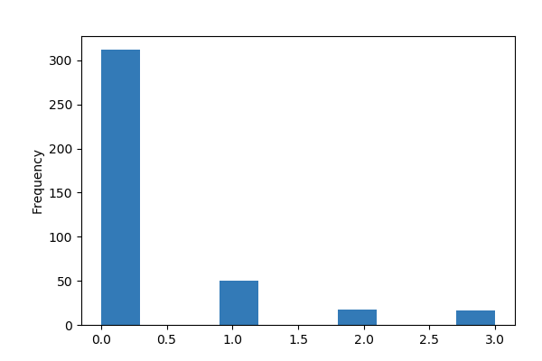

**Common Values**

| Value | Count | Frequency (%) |  |
| --- | --- | --- | --- |
| 0 | 312 | 79.0% |  |
| 1 | 50 | 12.7% |  |
| 2 | 17 | 4.3% |  |
| 3 | 16 | 4.1% |  |

**Extreme Values**

Minimum 5 values

| Value | Count | Frequency (%) |  |
| --- | --- | --- | --- |
| 0 | 312 | 79.0% |  |
| 1 | 50 | 12.7% |  |
| 2 | 17 | 4.3% |  |
| 3 | 16 | 4.1% |  |

Maximum 5 values

| Value | Count | Frequency (%) |  |
| --- | --- | --- | --- |
| 0 | 312 | 79.0% |  |
| 1 | 50 | 12.7% |  |
| 2 | 17 | 4.3% |  |
| 3 | 16 | 4.1% |  |

famrel  
Numeric

| Distinct count | 5 |
| --- | --- |
| Unique (%) | 1.3% |
| Missing (%) | 0.0% |
| Missing (n) | 0 |
| Infinite (%) | 0.0% |
| Infinite (n) | 0 |

| Mean | 3.9443 |
| --- | --- |
| Minimum | 1 |
| Maximum | 5 |
| Zeros (%) | 0.0% |

Toggle details

**Statistics**

Quantile statistics

| Minimum | 1 |
| --- | --- |
| 5-th percentile | 2 |
| Q1 | 4 |
| Median | 4 |
| Q3 | 5 |
| 95-th percentile | 5 |
| Maximum | 5 |
| Range | 4 |
| Interquartile range | 1 |

Descriptive statistics

| Standard deviation | 0.89666 |
| --- | --- |
| Coef of variation | 0.22733 |
| Kurtosis | 1.1398 |
| Mean | 3.9443 |
| MAD | 0.62159 |
| Skewness | -0.95188 |
| Sum | 1558 |
| Variance | 0.804 |
| Memory size | 3.2 KiB |

**Histogram**

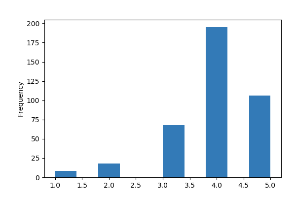

**Common Values**

| Value | Count | Frequency (%) |  |
| --- | --- | --- | --- |
| 4 | 195 | 49.4% |  |
| 5 | 106 | 26.8% |  |
| 3 | 68 | 17.2% |  |
| 2 | 18 | 4.6% |  |
| 1 | 8 | 2.0% |  |

**Extreme Values**

Minimum 5 values

| Value | Count | Frequency (%) |  |
| --- | --- | --- | --- |
| 1 | 8 | 2.0% |  |
| 2 | 18 | 4.6% |  |
| 3 | 68 | 17.2% |  |
| 4 | 195 | 49.4% |  |
| 5 | 106 | 26.8% |  |

Maximum 5 values

| Value | Count | Frequency (%) |  |
| --- | --- | --- | --- |
| 1 | 8 | 2.0% |  |
| 2 | 18 | 4.6% |  |
| 3 | 68 | 17.2% |  |
| 4 | 195 | 49.4% |  |
| 5 | 106 | 26.8% |  |

famsize  
Boolean

| Distinct count | 2 |
| --- | --- |
| Unique (%) | 0.5% |
| Missing (%) | 0.0% |
| Missing (n) | 0 |

| Mean | 0.28861 |
| --- | --- |

| 0 | 281 |
| --- | --- |
| 1 | 114 |

Toggle details

| Value | Count | Frequency (%) |  |
| --- | --- | --- | --- |
| 0 | 281 | 71.1% |  |
| 1 | 114 | 28.9% |  |

famsup  
Boolean

| Distinct count | 2 |
| --- | --- |
| Unique (%) | 0.5% |
| Missing (%) | 0.0% |
| Missing (n) | 0 |

| Mean | 0.61266 |
| --- | --- |

| 1 | 242 |
| --- | --- |
| 0 | 153 |

Toggle details

| Value | Count | Frequency (%) |  |
| --- | --- | --- | --- |
| 1 | 242 | 61.3% |  |
| 0 | 153 | 38.7% |  |

freetime  
Numeric

| Distinct count | 5 |
| --- | --- |
| Unique (%) | 1.3% |
| Missing (%) | 0.0% |
| Missing (n) | 0 |
| Infinite (%) | 0.0% |
| Infinite (n) | 0 |

| Mean | 3.2354 |
| --- | --- |
| Minimum | 1 |
| Maximum | 5 |
| Zeros (%) | 0.0% |

Toggle details

**Statistics**

Quantile statistics

| Minimum | 1 |
| --- | --- |
| 5-th percentile | 2 |
| Q1 | 3 |
| Median | 3 |
| Q3 | 4 |
| 95-th percentile | 5 |
| Maximum | 5 |
| Range | 4 |
| Interquartile range | 1 |

Descriptive statistics

| Standard deviation | 0.99886 |
| --- | --- |
| Coef of variation | 0.30872 |
| Kurtosis | -0.30181 |
| Mean | 3.2354 |
| MAD | 0.80256 |
| Skewness | -0.16335 |
| Sum | 1278 |
| Variance | 0.99773 |
| Memory size | 3.2 KiB |

**Histogram**

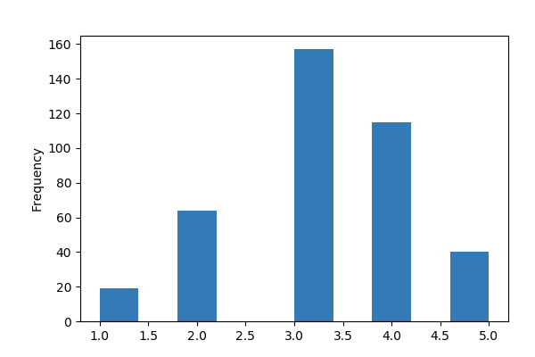

**Common Values**

| Value | Count | Frequency (%) |  |
| --- | --- | --- | --- |
| 3 | 157 | 39.7% |  |
| 4 | 115 | 29.1% |  |
| 2 | 64 | 16.2% |  |
| 5 | 40 | 10.1% |  |
| 1 | 19 | 4.8% |  |

**Extreme Values**

Minimum 5 values

| Value | Count | Frequency (%) |  |
| --- | --- | --- | --- |
| 1 | 19 | 4.8% |  |
| 2 | 64 | 16.2% |  |
| 3 | 157 | 39.7% |  |
| 4 | 115 | 29.1% |  |
| 5 | 40 | 10.1% |  |

Maximum 5 values

| Value | Count | Frequency (%) |  |
| --- | --- | --- | --- |
| 1 | 19 | 4.8% |  |
| 2 | 64 | 16.2% |  |
| 3 | 157 | 39.7% |  |
| 4 | 115 | 29.1% |  |
| 5 | 40 | 10.1% |  |

goout  
Numeric

| Distinct count | 5 |
| --- | --- |
| Unique (%) | 1.3% |
| Missing (%) | 0.0% |
| Missing (n) | 0 |
| Infinite (%) | 0.0% |
| Infinite (n) | 0 |

| Mean | 3.1089 |
| --- | --- |
| Minimum | 1 |
| Maximum | 5 |
| Zeros (%) | 0.0% |

Toggle details

**Statistics**

Quantile statistics

| Minimum | 1 |
| --- | --- |
| 5-th percentile | 1 |
| Q1 | 2 |
| Median | 3 |
| Q3 | 4 |
| 95-th percentile | 5 |
| Maximum | 5 |
| Range | 4 |
| Interquartile range | 2 |

Descriptive statistics

| Standard deviation | 1.1133 |
| --- | --- |
| Coef of variation | 0.3581 |
| Kurtosis | -0.77025 |
| Mean | 3.1089 |
| MAD | 0.89554 |
| Skewness | 0.1165 |
| Sum | 1228 |
| Variance | 1.2394 |
| Memory size | 3.2 KiB |

**Histogram**

[8 more figures not shown]

Sample

|  | school | sex | age | address | famsize | Pstatus | Medu | Fedu | Mjob | Fjob | reason | guardian | traveltime | studytime | failures | schoolsup | famsup | paid | activities | nursery | higher | internet | romantic | famrel | freetime | goout | Dalc | Walc | health | … |
| --- | --- | --- | --- | --- | --- | --- | --- | --- | --- | --- | --- | --- | --- | --- | --- | --- | --- | --- | --- | --- | --- | --- | --- | --- | --- | --- | --- | --- | --- | --- |
| 0 | 0 | 0 | 18 | 1 | 0 | 0 | 4 | 4 | 0 | 4 | 0 | 1 | 2 | 2 | 0 | 1 | 0 | 0 | 0 | 1 | 1 | 0 | 0 | 4 | 3 | 4 | 1 | 1 | 3 | … |
| 1 | 0 | 0 | 17 | 1 | 0 | 1 | 1 | 1 | 0 | 2 | 0 | 0 | 1 | 2 | 0 | 0 | 1 | 0 | 0 | 0 | 1 | 1 | 0 | 5 | 3 | 3 | 1 | 1 | 3 | … |
| 2 | 0 | 0 | 15 | 1 | 1 | 1 | 1 | 1 | 0 | 2 | 2 | 1 | 1 | 2 | 3 | 1 | 0 | 1 | 0 | 1 | 1 | 1 | 0 | 4 | 3 | 2 | 2 | 3 | 3 | … |
| 3 | 0 | 0 | 15 | 1 | 0 | 1 | 4 | 2 | 1 | 3 | 1 | 1 | 1 | 3 | 0 | 0 | 1 | 1 | 1 | 1 | 1 | 1 | 1 | 3 | 2 | 2 | 1 | 1 | 5 | … |
| 4 | 0 | 0 | 16 | 1 | 0 | 1 | 3 | 3 | 2 | 2 | 1 | 0 | 1 | 2 | 0 | 0 | 1 | 1 | 0 | 1 | 1 | 0 | 0 | 4 | 3 | 2 | 1 | 2 | 5 | … |

```python
#Estadicas por variable
pandas_profiling.ProfileReport(df)
```

```python
# De los coefcientes de Pearson y Spearman, se observan que en general las variables se encuentran menos correllacionas.
## hay un grado de correcacion importante entre la variables : Correclacion Positiva: Medu -Fedu, Medu-Mjob, goout-Walc
# Correlacion negavita : failures-Avg, principalmnete.
# Para efectos de analisis de algoritmo K-means se hace el analisis con las variables seleccionadas.
```

```python
df.head()
```

|  | school | sex | age | address | famsize | Pstatus | Medu | Fedu | Mjob | Fjob | ... | internet | romantic | famrel | freetime | goout | Dalc | Walc | health | absences | Avg |
| --- | --- | --- | --- | --- | --- | --- | --- | --- | --- | --- | --- | --- | --- | --- | --- | --- | --- | --- | --- | --- | --- |
| 0 | 0 | 0 | 18 | 1 | 0 | 0 | 4 | 4 | 0 | 4 | ... | 0 | 0 | 4 | 3 | 4 | 1 | 1 | 3 | 6 | 5.7 |
| 1 | 0 | 0 | 17 | 1 | 0 | 1 | 1 | 1 | 0 | 2 | ... | 1 | 0 | 5 | 3 | 3 | 1 | 1 | 3 | 4 | 5.3 |
| 2 | 0 | 0 | 15 | 1 | 1 | 1 | 1 | 1 | 0 | 2 | ... | 1 | 0 | 4 | 3 | 2 | 2 | 3 | 3 | 10 | 8.3 |
| 3 | 0 | 0 | 15 | 1 | 0 | 1 | 4 | 2 | 1 | 3 | ... | 1 | 1 | 3 | 2 | 2 | 1 | 1 | 5 | 2 | 14.7 |
| 4 | 0 | 0 | 16 | 1 | 0 | 1 | 3 | 3 | 2 | 2 | ... | 0 | 0 | 4 | 3 | 2 | 1 | 2 | 5 | 4 | 8.7 |

5 rows × 31 columns

# Construccion Modelo aprendizaje K-Means

```python
data = np.array(df)
```

```python
data.shape
```

```
(395, 31)
```

```python
data
```

```
array([[ 0. ,  0. , 18. , ...,  3. ,  6. ,  5.7],
       [ 0. ,  0. , 17. , ...,  3. ,  4. ,  5.3],
       [ 0. ,  0. , 15. , ...,  3. , 10. ,  8.3],
       ...,
       [ 1. ,  1. , 21. , ...,  3. ,  3. ,  8.3],
       [ 1. ,  1. , 18. , ...,  5. ,  0. , 11. ],
       [ 1. ,  1. , 19. , ...,  5. ,  5. ,  8.7]])
```

#### Determinar numero de estudiantes: 0: no beben - 1: Bebedores

```python
df_full.groupby(['Drink']).count()['Alc']
```

```
Drink
0    324
1     71
Name: Alc, dtype: int64
```

## Determinar numero optimo de grupos por Curva "Elbow"

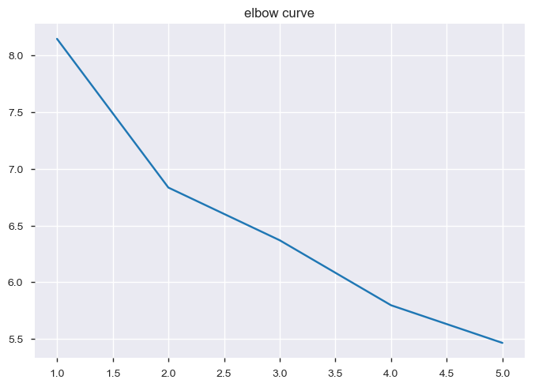

```python
from scipy.spatial.distance import cdist
res = list()
n_cluster = range(1,6)
for n in n_cluster:
    kmeans = KMeans(n_clusters=n)
    kmeans.fit(data)
    res.append(np.average(np.min(cdist(data, kmeans.cluster_centers_, 'euclidean'), axis=1)))

plt.plot(n_cluster, res)
plt.title('elbow curve')
plt.show()
```

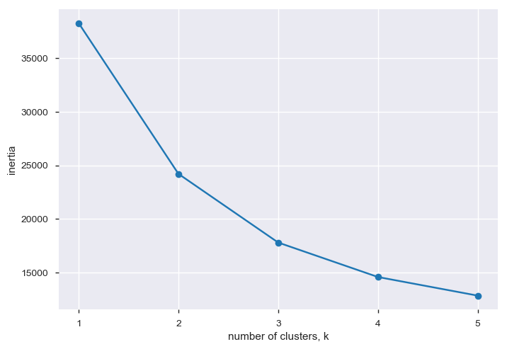

```python
ks = range(1, 6)
inertias = []

for k in ks:
    model = KMeans(n_clusters=k)
    model.fit(data)
    # Append the inertia to the list of inertias
    inertias.append(model.inertia_)

# Plot ks vs inertias
plt.plot(ks, inertias, '-o')
plt.xlabel('number of clusters, k')
plt.ylabel('inertia')
plt.xticks(ks)
plt.show()
```

### Se observa que el numero optimo de grupos es dos

## Evaluar resultados para datos sin normalizar Datos y n_clusters=2

```python
kmeans_class_eva(data)
```

```
drink     0   1
labels
0       279  52
1        45  19
```

```python
kmeans_silueta_eva(data)
```

```
Para n_clusters =  2  El Valor del coeficiente silueta es : 0.4576981421449367
Para n_clusters =  3  El Valor del coeficiente silueta es : 0.37783954882676823
Para n_clusters =  4  El Valor del coeficiente silueta es : 0.22074369952079043
Para n_clusters =  5  El Valor del coeficiente silueta es : 0.20432363742097484
Para n_clusters =  6  El Valor del coeficiente silueta es : 0.16424990714136414
Para n_clusters =  7  El Valor del coeficiente silueta es : 0.17260162167842735
Para n_clusters =  8  El Valor del coeficiente silueta es : 0.15001291299831934
Para n_clusters =  9  El Valor del coeficiente silueta es : 0.1503939606807118
```

```python
# Comparar resultado con metodo de inicializacion : k-means++
model = KMeans(n_clusters=2,init="k-means++")

# Use fit_predict to fit model and obtain cluster labels: labels
labels = model.fit_predict(data)


# Create a DataFrame with labels and varieties as columns: df
df_ = pd.DataFrame({'labels': labels, 'drink': df_full['Drink']})

# Create crosstab: ct
ct = pd.crosstab(df_['labels'],df_['drink'])

# Display ct
print(ct)
```

```
drink     0   1
labels
0       279  52
1        45  19
```

```python
# Comparar resultado con metodo de inicializacion : elkan
model = KMeans(n_clusters=2, algorithm='elkan')

# Use fit_predict to fit model and obtain cluster labels: labels
labels = model.fit_predict(data)


# Create a DataFrame with labels and varieties as columns: df
df_ = pd.DataFrame({'labels': labels, 'drink': df_full['Drink']})

# Create crosstab: ct
ct = pd.crosstab(df_['labels'],df_['drink'])

# Display ct
print(ct)
```

```
drink     0   1
labels
0       279  52
1        45  19
```

### Observaciones de Resultados

```python
result = pd.concat([df_full, df_], axis=1, sort=False)
#result
```

```python
result[(result.Drink ==1) & (result.labels ==0)].describe()
```

|  | age | Medu | Fedu | traveltime | studytime | failures | famrel | freetime | goout | Dalc | Walc | health | absences | G1 | G2 | G3 | Alc | Drink | labels | drink |
| --- | --- | --- | --- | --- | --- | --- | --- | --- | --- | --- | --- | --- | --- | --- | --- | --- | --- | --- | --- | --- |
| count | 52.000000 | 52.000000 | 52.000000 | 52.000000 | 52.000000 | 52.000000 | 52.000000 | 52.000000 | 52.000000 | 52.000000 | 52.000000 | 52.000000 | 52.000000 | 52.000000 | 52.000000 | 52.000000 | 52.000000 | 52.0 | 52.0 | 52.0 |
| mean | 16.711538 | 2.596154 | 2.403846 | 1.673077 | 1.596154 | 0.480769 | 3.730769 | 3.692308 | 3.884615 | 2.903846 | 4.096154 | 3.923077 | 3.538462 | 10.480769 | 10.365385 | 10.057692 | 3.384615 | 1.0 | 0.0 | 1.0 |
| std | 1.362474 | 1.175895 | 1.142059 | 0.984610 | 0.822708 | 0.896406 | 1.068541 | 0.919046 | 1.096409 | 0.975376 | 0.773574 | 1.412079 | 3.183669 | 2.733169 | 3.514836 | 4.113171 | 0.690378 | 0.0 | 0.0 | 0.0 |
| min | 15.000000 | 0.000000 | 1.000000 | 1.000000 | 1.000000 | 0.000000 | 1.000000 | 2.000000 | 1.000000 | 2.000000 | 2.000000 | 1.000000 | 0.000000 | 6.000000 | 0.000000 | 0.000000 | 3.000000 | 1.0 | 0.0 | 1.0 |
| 25% | 16.000000 | 2.000000 | 1.000000 | 1.000000 | 1.000000 | 0.000000 | 3.000000 | 3.000000 | 3.000000 | 2.000000 | 4.000000 | 3.000000 | 0.000000 | 8.000000 | 8.750000 | 9.000000 | 3.000000 | 1.0 | 0.0 | 1.0 |
| 50% | 16.500000 | 3.000000 | 2.000000 | 1.000000 | 1.000000 | 0.000000 | 4.000000 | 4.000000 | 4.000000 | 3.000000 | 4.000000 | 5.000000 | 3.500000 | 10.000000 | 10.500000 | 10.000000 | 3.000000 | 1.0 | 0.0 | 1.0 |
| 75% | 18.000000 | 4.000000 | 3.250000 | 2.000000 | 2.000000 | 1.000000 | 4.250000 | 4.000000 | 5.000000 | 3.000000 | 5.000000 | 5.000000 | 6.000000 | 12.250000 | 13.000000 | 13.000000 | 4.000000 | 1.0 | 0.0 | 1.0 |
| max | 21.000000 | 4.000000 | 4.000000 | 4.000000 | 4.000000 | 3.000000 | 5.000000 | 5.000000 | 5.000000 | 5.000000 | 5.000000 | 5.000000 | 10.000000 | 18.000000 | 18.000000 | 18.000000 | 5.000000 | 1.0 | 0.0 | 1.0 |

```python
result[(result.Drink ==1) & (result.labels ==1)].describe()
```

|  | age | Medu | Fedu | traveltime | studytime | failures | famrel | freetime | goout | Dalc | Walc | health | absences | G1 | G2 | G3 | Alc | Drink | labels | drink |
| --- | --- | --- | --- | --- | --- | --- | --- | --- | --- | --- | --- | --- | --- | --- | --- | --- | --- | --- | --- | --- |
| count | 19.000000 | 19.000000 | 19.000000 | 19.000000 | 19.000000 | 19.000000 | 19.000000 | 19.000000 | 19.000000 | 19.000000 | 19.000000 | 19.000000 | 19.000000 | 19.000000 | 19.000000 | 19.000000 | 19.000000 | 19.0 | 19.0 | 19.0 |
| mean | 17.578947 | 3.105263 | 2.684211 | 1.368421 | 1.736842 | 0.894737 | 4.157895 | 3.631579 | 4.105263 | 3.263158 | 4.315789 | 3.789474 | 18.578947 | 8.684211 | 8.578947 | 8.631579 | 3.631579 | 1.0 | 1.0 | 1.0 |
| std | 1.502435 | 0.875261 | 1.108183 | 0.760886 | 0.561951 | 1.048530 | 0.602140 | 1.116071 | 0.936586 | 1.097578 | 0.671038 | 1.474937 | 9.968371 | 2.849028 | 2.968647 | 3.058876 | 0.760886 | 0.0 | 0.0 | 0.0 |
| min | 16.000000 | 1.000000 | 1.000000 | 1.000000 | 1.000000 | 0.000000 | 3.000000 | 1.000000 | 2.000000 | 2.000000 | 3.000000 | 1.000000 | 11.000000 | 6.000000 | 5.000000 | 4.000000 | 3.000000 | 1.0 | 1.0 | 1.0 |
| 25% | 17.000000 | 3.000000 | 2.000000 | 1.000000 | 1.000000 | 0.000000 | 4.000000 | 3.000000 | 3.500000 | 2.000000 | 4.000000 | 3.000000 | 13.500000 | 6.000000 | 6.500000 | 7.500000 | 3.000000 | 1.0 | 1.0 | 1.0 |
| 50% | 17.000000 | 3.000000 | 3.000000 | 1.000000 | 2.000000 | 1.000000 | 4.000000 | 4.000000 | 4.000000 | 3.000000 | 4.000000 | 4.000000 | 15.000000 | 8.000000 | 8.000000 | 8.000000 | 3.000000 | 1.0 | 1.0 | 1.0 |
| 75% | 18.000000 | 4.000000 | 4.000000 | 1.500000 | 2.000000 | 1.500000 | 4.500000 | 4.000000 | 5.000000 | 4.000000 | 5.000000 | 5.000000 | 18.500000 | 10.000000 | 9.000000 | 9.500000 | 4.000000 | 1.0 | 1.0 | 1.0 |
| max | 22.000000 | 4.000000 | 4.000000 | 4.000000 | 3.000000 | 3.000000 | 5.000000 | 5.000000 | 5.000000 | 5.000000 | 5.000000 | 5.000000 | 54.000000 | 17.000000 | 17.000000 | 17.000000 | 5.000000 | 1.0 | 1.0 | 1.0 |

```python
result[(result.Drink ==0) & (result.labels ==0)].describe()
```

|  | age | Medu | Fedu | traveltime | studytime | failures | famrel | freetime | goout | Dalc | Walc | health | absences | G1 | G2 | G3 | Alc | Drink | labels | drink |
| --- | --- | --- | --- | --- | --- | --- | --- | --- | --- | --- | --- | --- | --- | --- | --- | --- | --- | --- | --- | --- |
| count | 279.000000 | 279.000000 | 279.000000 | 279.000000 | 279.000000 | 279.00000 | 279.000000 | 279.000000 | 279.000000 | 279.000000 | 279.000000 | 279.000000 | 279.000000 | 279.000000 | 279.000000 | 279.000000 | 279.000000 | 279.0 | 279.0 | 279.0 |
| mean | 16.551971 | 2.741935 | 2.534050 | 1.422939 | 2.164875 | 0.25448 | 4.017921 | 3.143369 | 2.917563 | 1.150538 | 1.838710 | 3.505376 | 3.010753 | 11.096774 | 10.928315 | 10.562724 | 1.322581 | 0.0 | 0.0 | 0.0 |
| std | 1.218851 | 1.108209 | 1.078612 | 0.640630 | 0.849070 | 0.69150 | 0.841612 | 0.941194 | 1.005567 | 0.358240 | 0.962876 | 1.372576 | 3.094999 | 3.443473 | 3.932235 | 4.929230 | 0.468304 | 0.0 | 0.0 | 0.0 |
| min | 15.000000 | 0.000000 | 0.000000 | 1.000000 | 1.000000 | 0.00000 | 1.000000 | 1.000000 | 1.000000 | 1.000000 | 1.000000 | 1.000000 | 0.000000 | 3.000000 | 0.000000 | 0.000000 | 1.000000 | 0.0 | 0.0 | 0.0 |
| 25% | 16.000000 | 2.000000 | 2.000000 | 1.000000 | 2.000000 | 0.00000 | 4.000000 | 3.000000 | 2.000000 | 1.000000 | 1.000000 | 3.000000 | 0.000000 | 8.000000 | 9.000000 | 9.000000 | 1.000000 | 0.0 | 0.0 | 0.0 |
| 50% | 16.000000 | 3.000000 | 3.000000 | 1.000000 | 2.000000 | 0.00000 | 4.000000 | 3.000000 | 3.000000 | 1.000000 | 2.000000 | 4.000000 | 2.000000 | 11.000000 | 11.000000 | 11.000000 | 1.000000 | 0.0 | 0.0 | 0.0 |
| 75% | 18.000000 | 4.000000 | 3.000000 | 2.000000 | 3.000000 | 0.00000 | 5.000000 | 4.000000 | 4.000000 | 1.000000 | 3.000000 | 5.000000 | 5.000000 | 14.000000 | 14.000000 | 14.000000 | 2.000000 | 0.0 | 0.0 | 0.0 |
| max | 20.000000 | 4.000000 | 4.000000 | 4.000000 | 4.000000 | 3.00000 | 5.000000 | 5.000000 | 5.000000 | 2.000000 | 5.000000 | 5.000000 | 11.000000 | 19.000000 | 19.000000 | 20.000000 | 2.000000 | 0.0 | 0.0 | 0.0 |

#### Como resultado se obtiene que el modelo clasifica en un grupo 279 estudiantes “no bebedores” de un total de 324, es decir agrupa al 86% de estos estudiantes. Por otra parte en el grupo de “bebedores” ubico 19 estudiantes de un total de 71, es decir el 26.7%.

#### Al comparar las estadísticas básicas de estos dos grupos, se observa que la principal diferencia entre los que fueron clasificados como "no bebedores" por el modelo , siendo, por clase "bebedores", frente a los agrupados correctamente como "Bebedores", es básicamente en al atributo "absences" que para este grupo tiene un valor bajo en comparación, y relativamente cercana a los clasificados efectivamente como no bebedores.

#### De acuerdo con los resultados obtenidos del coeficiente silueta se observa que el mejor comportamiento para este coeficiente se obtiene con n_clusters = 2

## Evaluacion Modelo Kmeans estandarizando datos

```python
data
```

```
array([[ 0. ,  0. , 18. , ...,  3. ,  6. ,  5.7],
       [ 0. ,  0. , 17. , ...,  3. ,  4. ,  5.3],
       [ 0. ,  0. , 15. , ...,  3. , 10. ,  8.3],
       ...,
       [ 1. ,  1. , 21. , ...,  3. ,  3. ,  8.3],
       [ 1. ,  1. , 18. , ...,  5. ,  0. , 11. ],
       [ 1. ,  1. , 19. , ...,  5. ,  5. ,  8.7]])
```

#### 1- Normalizacion StandardScaler()

```python
scaler = StandardScaler()
kmeans = KMeans(n_clusters =2)
pipeline = make_pipeline(scaler,kmeans)
pipeline.fit(data)
labels =pipeline.predict(data)
df1= pd.DataFrame({'labels':labels,'drink':df_full['Drink']})
ct =pd.crosstab(df1['labels'],df1['drink'])
ct
```

| drink labels | 0 | 1 |
| --- | --- | --- |
| 0 | 216 | 35 |
| 1 | 108 | 36 |

#### 2- Normalizacion StandardScaler()

```python
scaler = StandardScaler()
scaler.fit(data)
StandardScaler(copy = True,with_mean=True,with_std=True)
data_normal_ = scaler.transform(data)
```

```python
kmeans_class_eva(data_normal_)
```

```
drink     0   1
labels
0       224  32
1       100  39
```

```python
kmeans_silueta_eva(data_normal_)
```

```
Para n_clusters =  2  El Valor del coeficiente silueta es : 0.08949502344534403
Para n_clusters =  3  El Valor del coeficiente silueta es : 0.04706279368806067
Para n_clusters =  4  El Valor del coeficiente silueta es : 0.06344801210407436
Para n_clusters =  5  El Valor del coeficiente silueta es : 0.04581508789026971
Para n_clusters =  6  El Valor del coeficiente silueta es : 0.05613280554959423
Para n_clusters =  7  El Valor del coeficiente silueta es : 0.04698238955607505
Para n_clusters =  8  El Valor del coeficiente silueta es : 0.04626981375427368
Para n_clusters =  9  El Valor del coeficiente silueta es : 0.04807978938534056
```

#### 3- Normalizacion MinMaxScaler()

```python
min_max_scaler = preprocessing.MinMaxScaler()
data_normal_ = min_max_scaler.fit_transform(data)
```

```python
kmeans_class_eva(data_normal_)
```

```
drink     0   1
labels
0       194  14
1       130  57
```

```python
kmeans_silueta_eva(data_normal_)
```

```
Para n_clusters =  2  El Valor del coeficiente silueta es : 0.08444121242043033
Para n_clusters =  3  El Valor del coeficiente silueta es : 0.07117662056213706
Para n_clusters =  4  El Valor del coeficiente silueta es : 0.07671105009577495
Para n_clusters =  5  El Valor del coeficiente silueta es : 0.07268641843090756
Para n_clusters =  6  El Valor del coeficiente silueta es : 0.0646463600897228
Para n_clusters =  7  El Valor del coeficiente silueta es : 0.06631244544938214
Para n_clusters =  8  El Valor del coeficiente silueta es : 0.06659372763387002
Para n_clusters =  9  El Valor del coeficiente silueta es : 0.06859330262277945
```

#### 4- Normalizacion MaxAbsScaler()

```python
min_max_scaler = preprocessing.MaxAbsScaler()
data_normal_ = min_max_scaler.fit_transform(data)
```

```python
kmeans_class_eva(data_normal_)
```

```
drink     0   1
labels
0       177  37
1       147  34
```

```python
kmeans_silueta_eva(data_normal_)
```

```
Para n_clusters =  2  El Valor del coeficiente silueta es : 0.08618064219697569
Para n_clusters =  3  El Valor del coeficiente silueta es : 0.076253987818266
Para n_clusters =  4  El Valor del coeficiente silueta es : 0.078818298551903
Para n_clusters =  5  El Valor del coeficiente silueta es : 0.07722757294340163
Para n_clusters =  6  El Valor del coeficiente silueta es : 0.07428426735135253
Para n_clusters =  7  El Valor del coeficiente silueta es : 0.07684786587636266
Para n_clusters =  8  El Valor del coeficiente silueta es : 0.06104384455910098
Para n_clusters =  9  El Valor del coeficiente silueta es : 0.07104550677379894
```

#### En términos generales se observa que estandarizando o normalizando datos NO se obtiene un desempeño mejor en la agrupación en comparación con el atributo clase.

#### Se observa que normalizando datos con MinMaxScaler, tiene un mejor comportamiento en la agrupación de los "bebedores" con 57 ubicados en este grupo, que es cerca al 80% de los clasificados originalmente en este grupo, entre tanto agrupa el 60% de los "No bebedores" en el mismos cluster, de acuerdo con la clasificación por "classe".

## Evaluacion Modelo Kmeans reduciendo dimensionalidad mediante PCA

#### PCA Datos Sin Normalizar

```python
pca = PCA(n_components=2)
principalComponents = pca.fit_transform(data)
```

```python
kmeans_class_eva(principalComponents)
```

```
drink     0   1
labels
0       279  52
1        45  19
```

```python
kmeans_silueta_eva(principalComponents)
```

```
Para n_clusters =  2  El Valor del coeficiente silueta es : 0.5718405517363204
Para n_clusters =  3  El Valor del coeficiente silueta es : 0.5141221849788304
Para n_clusters =  4  El Valor del coeficiente silueta es : 0.38803467508636935
Para n_clusters =  5  El Valor del coeficiente silueta es : 0.39343192522118736
Para n_clusters =  6  El Valor del coeficiente silueta es : 0.38754063386412124
Para n_clusters =  7  El Valor del coeficiente silueta es : 0.3812022034452436
Para n_clusters =  8  El Valor del coeficiente silueta es : 0.39300486408159113
Para n_clusters =  9  El Valor del coeficiente silueta es : 0.3895788279796203
```

#### Visualizacion clusters PCA por coeficiente silueta

#### Tomado de: https://scikit-learn.org/stable/auto_examples/cluster/plot_kmeans_silhouette_analysis.html

```
Automatically created module for IPython interactive environment
For n_clusters = 2 The average silhouette_score is : 0.5718405517363204
For n_clusters = 3 The average silhouette_score is : 0.5141221849788304
For n_clusters = 4 The average silhouette_score is : 0.38803467508636935
For n_clusters = 5 The average silhouette_score is : 0.39343192522118736
For n_clusters = 6 The average silhouette_score is : 0.3779596498978244
```

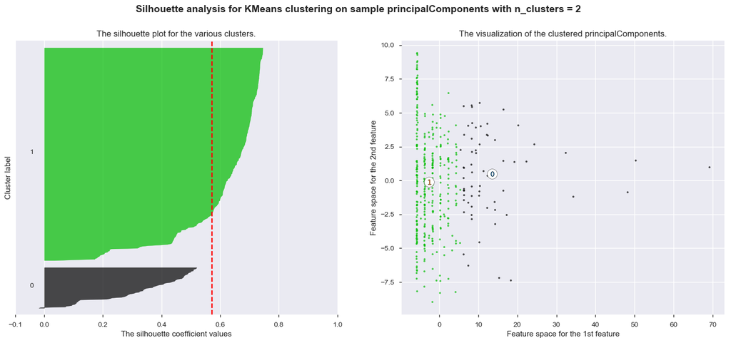

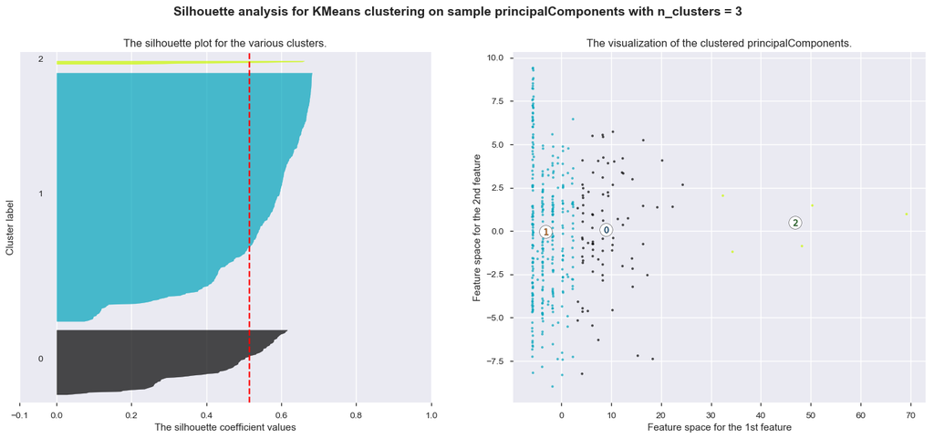

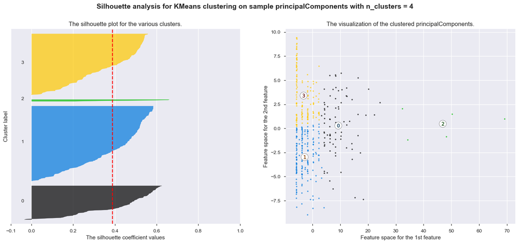

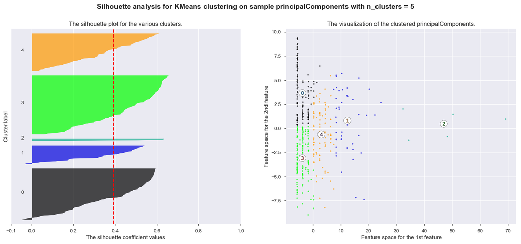

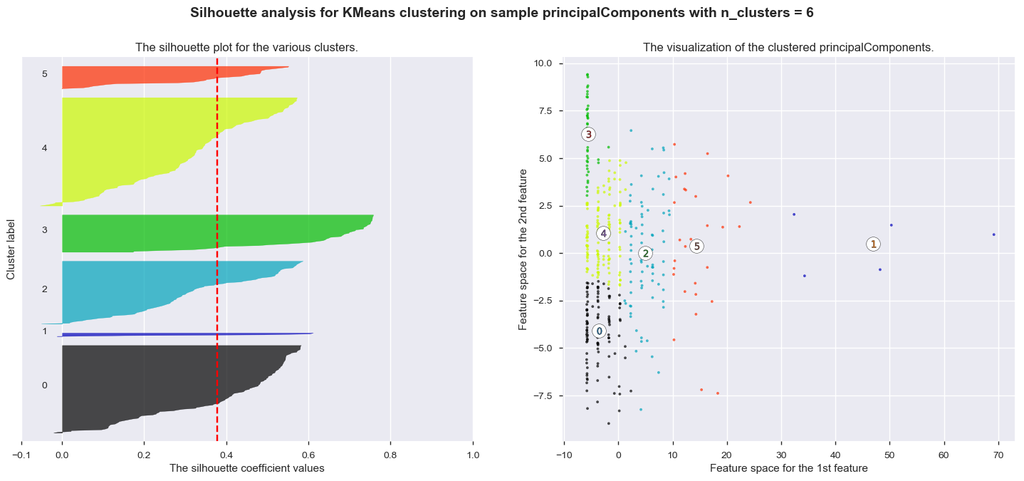

```python
from __future__ import print_function

from sklearn.datasets import make_blobs
from sklearn.cluster import KMeans
from sklearn.metrics import silhouette_samples, silhouette_score

import matplotlib.pyplot as plt
import matplotlib.cm as cm
import numpy as np

print(__doc__)

# Generating the sample principalComponents from make_blobs
# This particular setting has one distinct cluster and 3 clusters placed close
# together.

range_n_clusters = [2, 3, 4, 5, 6]

for n_clusters in range_n_clusters:
    # Create a subplot with 1 row and 2 columns
    fig, (ax1, ax2) = plt.subplots(1, 2)
    fig.set_size_inches(18, 7)

    # The 1st subplot is the silhouette plot
    # The silhouette coefficient can range from -1, 1 but in this example all
    # lie within [-0.1, 1]
    ax1.set_xlim([-0.1, 1])
    # The (n_clusters+1)*10 is for inserting blank space between silhouette
    # plots of individual clusters, to demarcate them clearly.
    ax1.set_ylim([0, len(principalComponents) + (n_clusters + 1) * 10])

    # Initialize the clusterer with n_clusters value and a random generator
    # seed of 10 for reproducibility.
    clusterer = KMeans(n_clusters=n_clusters, random_state=10)
    cluster_labels = clusterer.fit_predict(principalComponents)

    # The silhouette_score gives the average value for all the samples.
    # This gives a perspective into the density and separation of the formed
    # clusters
    silhouette_avg = silhouette_score(principalComponents, cluster_labels)
    print("For n_clusters =", n_clusters,
          "The average silhouette_score is :", silhouette_avg)

    # Compute the silhouette scores for each sample
    sample_silhouette_values = silhouette_samples(principalComponents, cluster_labels)

    y_lower = 10
    for i in range(n_clusters):
        # Aggregate the silhouette scores for samples belonging to
        # cluster i, and sort them
        ith_cluster_silhouette_values = \
            sample_silhouette_values[cluster_labels == i]

        ith_cluster_silhouette_values.sort()

        size_cluster_i = ith_cluster_silhouette_values.shape[0]
        y_upper = y_lower + size_cluster_i

        color = cm.nipy_spectral(float(i) / n_clusters)
        ax1.fill_betweenx(np.arange(y_lower, y_upper),
                          0, ith_cluster_silhouette_values,
                          facecolor=color, edgecolor=color, alpha=0.7)

        # Label the silhouette plots with their cluster numbers at the middle
        ax1.text(-0.05, y_lower + 0.5 * size_cluster_i, str(i))

        # Compute the new y_lower for next plot
        y_lower = y_upper + 10  # 10 for the 0 samples

    ax1.set_title("The silhouette plot for the various clusters.")
    ax1.set_xlabel("The silhouette coefficient values")
    ax1.set_ylabel("Cluster label")

    # The vertical line for average silhouette score of all the values
    ax1.axvline(x=silhouette_avg, color="red", linestyle="--")

    ax1.set_yticks([])  # Clear the yaxis labels / ticks
    ax1.set_xticks([-0.1, 0, 0.2, 0.4, 0.6, 0.8, 1])

    # 2nd Plot showing the actual clusters formed
    colors = cm.nipy_spectral(cluster_labels.astype(float) / n_clusters)
    ax2.scatter(principalComponents[:, 0], principalComponents[:, 1], marker='.', s=30, lw=0, alpha=0.7,
                c=colors, edgecolor='k')

    # Labeling the clusters
    centers = clusterer.cluster_centers_
    # Draw white circles at cluster centers
    ax2.scatter(centers[:, 0], centers[:, 1], marker='o',
                c="white", alpha=1, s=200, edgecolor='k')

    for i, c in enumerate(centers):
        ax2.scatter(c[0], c[1], marker='$%d$' % i, alpha=1,
                    s=50, edgecolor='k')

    ax2.set_title("The visualization of the clustered principalComponents.")
    ax2.set_xlabel("Feature space for the 1st feature")
    ax2.set_ylabel("Feature space for the 2nd feature")

    plt.suptitle(("Silhouette analysis for KMeans clustering on sample principalComponents "
                  "with n_clusters = %d" % n_clusters),
                 fontsize=14, fontweight='bold')

plt.show()
```

#### PCA Datos Normalizados

```python
scaler = StandardScaler()
scaler.fit(data)
StandardScaler(copy=True, with_mean=True, with_std=True)
data_normal = scaler.transform(data)
pca = PCA(n_components=2)
principalComponents = pca.fit_transform(data_normal)
```

```python
kmeans_class_eva(principalComponents)
```

```
drink     0   1
labels
0       243  35
1        81  36
```

```python
kmeans_silueta_eva(principalComponents)
```

```
Para n_clusters =  2  El Valor del coeficiente silueta es : 0.3893546454949694
Para n_clusters =  3  El Valor del coeficiente silueta es : 0.35754166686571814
Para n_clusters =  4  El Valor del coeficiente silueta es : 0.3584905961503481
Para n_clusters =  5  El Valor del coeficiente silueta es : 0.32826254638662394
Para n_clusters =  6  El Valor del coeficiente silueta es : 0.32599938709131754
Para n_clusters =  7  El Valor del coeficiente silueta es : 0.34417971868898317
Para n_clusters =  8  El Valor del coeficiente silueta es : 0.35814230111051343
Para n_clusters =  9  El Valor del coeficiente silueta es : 0.34885057865231855
```